# **Parking Slot Occupancy Detection**

### 4.1. Visualization

Missing Data Visualization Missing data visualization involves identifying and understanding gaps in a dataset using graphical techniques such as heatmaps, bar plots, or matrix plots. These visuals highlight patterns and proportions of missing values across features, aiding in informed decisions for data cleaning and imputation strategies during preprocessing.

#### 4.1.1. Heatmap

Display missing values across the dataset to identify patterns or areas where data is missing.

```python
import pandas as pd
import seaborn as sns
import matplotlib.pyplot as plt

# Load the dataset from the CSV file
file_path = r'C:\Users\ssgul\OneDrive\Documents\GitHub\MOP-Code\Playground\sgulluoglu\on-street-parking-bay-sensors.csv'
data = pd.read_csv(file_path)

# Display the first few rows and column names to inspect the data
print("Column names:", data.columns)
print("First few rows of the dataset:")
print(data.head())

# Identify missing values
missing_values = data.isnull().sum()

# Calculate the percentage of missing values
missing_percentage = (missing_values / len(data)) * 100

# Create a DataFrame to display missing values and their percentage
missing_data = pd.DataFrame({
    'Missing Values': missing_values,
    'Percentage of Missing Values (%)': missing_percentage
})

# Display the DataFrame with missing values information
print("Missing values information:")
print(missing_data)

# Create a heatmap for missing values
plt.figure(figsize=(12, 8))
sns.heatmap(data.isnull(), cbar=False, cmap='viridis', yticklabels=False, xticklabels=True)
plt.title('Heatmap of Missing Values')
plt.xlabel('Columns')
plt.ylabel('Rows')
plt.show()
```

[output not shown]

#### 4.1.2. Bar Plot

Show the percentage of missing data in each column to prioritize which columns need attention.

```python
import pandas as pd
import matplotlib.pyplot as plt

# Load the dataset from the CSV file
file_path = r'C:\Users\ssgul\OneDrive\Documents\GitHub\MOP-Code\Playground\sgulluoglu\on-street-parking-bay-sensors.csv'
data = pd.read_csv(file_path)

# Identify missing values
missing_values = data.isnull().sum()

# Calculate the percentage of missing values
missing_percentage = (missing_values / len(data)) * 100

# Create a DataFrame to display missing values and their percentage
missing_data = pd.DataFrame({
    'Missing Values': missing_values,
    'Percentage of Missing Values (%)': missing_percentage
})

# Display the DataFrame with missing values information
print("Missing values information:")
print(missing_data)

# Plot the percentage of missing values as a bar plot
plt.figure(figsize=(12, 8))
missing_data['Percentage of Missing Values (%)'].sort_values().plot(kind='barh', color='skyblue')
plt.title('Percentage of Missing Data in Each Column')
plt.xlabel('Percentage of Missing Values (%)')
plt.ylabel('Columns')
plt.show()
```

[output not shown]

```python
import pandas as pd
import pytz


file_path = r'C:\Users\ssgul\OneDrive\Documents\GitHub\MOP-Code\Playground\sgulluoglu\on-street-parking-bay-sensors.csv'
df = pd.read_csv(file_path)

# List the column names
print("Column Names:")
print(df.columns.tolist())

# Define the timezone conversion function
def convert_utc_to_melbourne(utc_time_str):
    utc_zone = pytz.utc
    melbourne_zone = pytz.timezone('Australia/Melbourne')

    # Convert the string to a datetime object
    utc_time = pd.to_datetime(utc_time_str, utc=True)

    # Convert to Melbourne time
    melbourne_time = utc_time.tz_convert(melbourne_zone)
    return melbourne_time

# List of columns to convert
columns_to_convert = ['Lastupdated', 'Status_Timestamp']

# Convert the specified columns
for column in columns_to_convert:
    if column in df.columns:
        df[column] = df[column].apply(lambda x: convert_utc_to_melbourne(x) if pd.notnull(x) else x)
        print(f"Updated Column: {column}")
    else:
        print(f"Column '{column}' not found in the data")

# List missing values
print("\nMissing Values:")
print(df.isnull().sum())

# Fill missing values with values from other columns/rows
# use forward fill and backward fill
df.fillna(method='ffill', inplace=True)  # Forward fill
df.fillna(method='bfill', inplace=True)  # Backward fill

# Recheck missing values
print("\nMissing Values After Filling:")
print(df.isnull().sum())

# Calculate the parking time
if 'Lastupdated' in df.columns and 'Status_Timestamp' in df.columns:
    df['parking_time'] = (df['Lastupdated'] - df['Status_Timestamp']).dt.total_seconds() / 60  # Convert to minutes
    print("\nDataFrame with Parking Time:")
    print(df[['Lastupdated', 'Status_Timestamp', 'parking_time']].head())
else:
    print("Required columns for parking time calculation are missing.")
```

[output not shown]

### 4.3. Comprehensive Parking Data Analysis with Timezone Conversion and Entry/Exit Trends Visualization

In this code, I performed a comprehensive analysis of parking data. The dataset was loaded and column names listed for clarity. A timezone conversion function was implemented to standardize timestamps from UTC to Melbourne time. Missing values were identified and handled using forward and backward filling methods to ensure data completeness. Parking time was calculated by subtracting timestamps, enabling detailed temporal analysis. Additionally, entry and exit trends were analyzed by grouping data based on hours and plotting histograms for visualization. These steps provided insights into hourly parking behavior, aiding in understanding peak usage times and optimizing parking management.

```
Column Names:
['Lastupdated', 'Status_Timestamp', 'Zone_Number', 'Status_Description', 'KerbsideID', 'Location']
Updated Column: Lastupdated
Updated Column: Status_Timestamp

Missing Values:
Lastupdated             0
Status_Timestamp        0
Zone_Number           501
Status_Description      0
KerbsideID              0
Location                0
dtype: int64

Missing Values After Filling:
Lastupdated           0
Status_Timestamp      0
Zone_Number           0
Status_Description    0
KerbsideID            0
Location              0
dtype: int64

DataFrame with Parking Time:
                Lastupdated          Status_Timestamp  parking_time
0 2023-12-14 15:45:34+11:00 2023-12-14 14:41:25+11:00     64.150000
1 2023-12-14 15:45:34+11:00 2023-12-13 17:21:58+11:00   1343.600000
2 2023-12-15 10:45:34+11:00 2023-12-15 10:35:02+11:00     10.533333
3 2023-12-15 10:45:34+11:00 2023-12-15 09:39:46+11:00     65.800000
4 2023-12-18 15:45:34+11:00 2023-12-18 10:47:54+11:00    297.666667
```

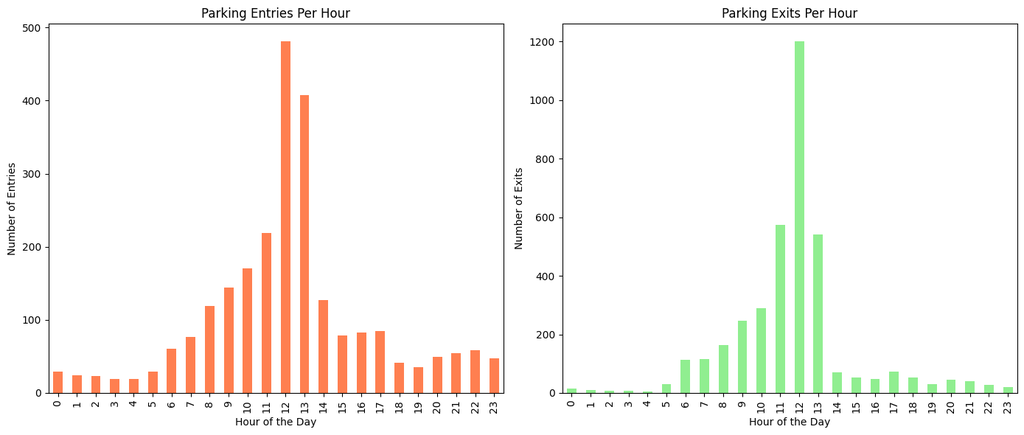

```python
import pandas as pd
import pytz
import matplotlib.pyplot as plt

# Load the dataset
file_path = r'C:\Users\ssgul\OneDrive\Documents\GitHub\MOP-Code\Playground\sgulluoglu\on-street-parking-bay-sensors.csv'
df = pd.read_csv(file_path)

# List the column names
print("Column Names:")
print(df.columns.tolist())

# Define the timezone conversion function
def convert_utc_to_melbourne(utc_time_str):
    utc_zone = pytz.utc
    melbourne_zone = pytz.timezone('Australia/Melbourne')

    # Convert the string to a datetime object
    utc_time = pd.to_datetime(utc_time_str, utc=True)

    # Convert to Melbourne time
    melbourne_time = utc_time.tz_convert(melbourne_zone)
    return melbourne_time

# List of columns to convert
columns_to_convert = ['Lastupdated', 'Status_Timestamp']

# Convert the specified columns
for column in columns_to_convert:
    if column in df.columns:
        df[column] = df[column].apply(lambda x: convert_utc_to_melbourne(x) if pd.notnull(x) else x)
        print(f"Updated Column: {column}")
    else:
        print(f"Column '{column}' not found in the data")

# List missing values
print("\nMissing Values:")
print(df.isnull().sum())

# Fill missing values with values from other columns/rows
df.fillna(method='ffill', inplace=True)  # Forward fill
df.fillna(method='bfill', inplace=True)  # Backward fill

# Recheck missing values
print("\nMissing Values After Filling:")
print(df.isnull().sum())

# Calculate the parking time
if 'Lastupdated' in df.columns and 'Status_Timestamp' in df.columns:
    df['parking_time'] = (df['Lastupdated'] - df['Status_Timestamp']).dt.total_seconds() / 60  # Convert to minutes
    print("\nDataFrame with Parking Time:")
    print(df[['Lastupdated', 'Status_Timestamp', 'parking_time']].head())
else:
    print("Required columns for parking time calculation are missing.")

# Extract the hour from Status_Timestamp
df['Hour'] = df['Status_Timestamp'].dt.hour

# Assuming 'Status_Description' has values 'Occupied' and 'Vacant' for entries and exits
entries_per_hour = df[df['Status_Description'] == 'Unoccupied'].groupby('Hour').size()
exits_per_hour = df[df['Status_Description'] == 'Present'].groupby('Hour').size()

# Plot histograms for Entries and Exits
plt.figure(figsize=(14, 6))

# Plot for Entries
plt.subplot(1, 2, 1)
entries_per_hour.plot(kind='bar', color='coral')
plt.title('Parking Entries Per Hour')
plt.xlabel('Hour of the Day')
plt.ylabel('Number of Entries')

# Plot for Exits
plt.subplot(1, 2, 2)
exits_per_hour.plot(kind='bar', color='lightgreen')
plt.title('Parking Exits Per Hour')
plt.xlabel('Hour of the Day')
plt.ylabel('Number of Exits')

plt.tight_layout()
plt.show()
```

### 4.4.Rolling Averages and Resampling for Parking Status Analysis

In this code, I performed an in-depth analysis of parking status trends by resampling the data to an hourly frequency. The dataset was loaded, and timestamps were converted to Melbourne time for accurate temporal analysis. I calculated the number of occupied parking bays per hour Status_Description and the mean parking time. A rolling average with a 24-hour window was computed to smooth fluctuations and reveal overall trends in parking occupancy. Additionally, histograms were plotted to visualize entry and exit trends, while line plots illustrated hourly occupied bays and their rolling averages, providing insights into peak and consistent usage periods.

```
Column Names:
['Lastupdated', 'Status_Timestamp', 'Zone_Number', 'Status_Description', 'KerbsideID', 'Location']
Updated Column: Lastupdated
Updated Column: Status_Timestamp

Missing Values:
Lastupdated             0
Status_Timestamp        0
Zone_Number           501
Status_Description      0
KerbsideID              0
Location                0
dtype: int64

Missing Values After Filling:
Lastupdated           0
Status_Timestamp      0
Zone_Number           0
Status_Description    0
KerbsideID            0
Location              0
dtype: int64

DataFrame with Parking Time:
                Lastupdated          Status_Timestamp  parking_time
0 2023-12-14 15:45:34+11:00 2023-12-14 14:41:25+11:00     64.150000
1 2023-12-14 15:45:34+11:00 2023-12-13 17:21:58+11:00   1343.600000
2 2023-12-15 10:45:34+11:00 2023-12-15 10:35:02+11:00     10.533333
3 2023-12-15 10:45:34+11:00 2023-12-15 09:39:46+11:00     65.800000
4 2023-12-18 15:45:34+11:00 2023-12-18 10:47:54+11:00    297.666667
```

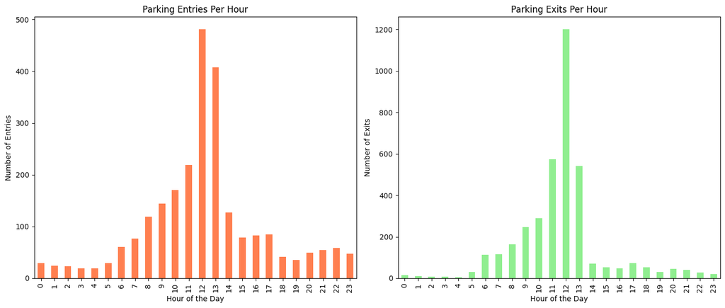

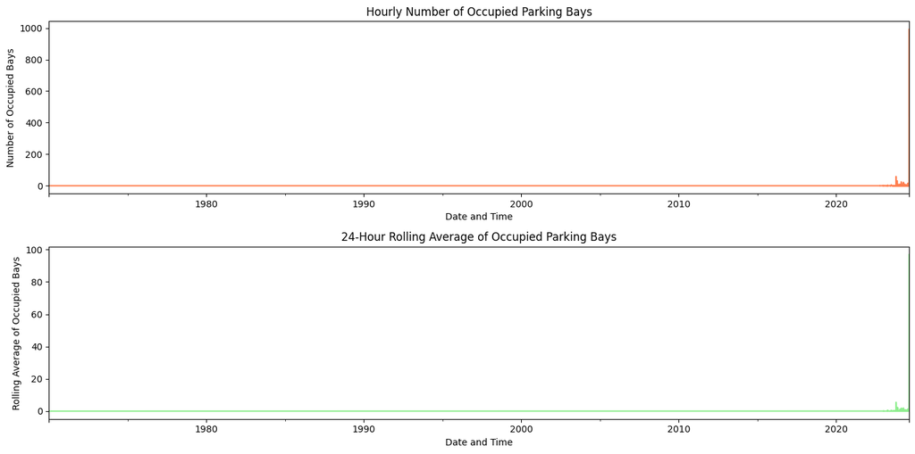

```python
import pandas as pd
import pytz
import matplotlib.pyplot as plt

# Load the dataset
file_path = r'C:\Users\ssgul\OneDrive\Documents\GitHub\MOP-Code\Playground\sgulluoglu\on-street-parking-bay-sensors.csv'
df = pd.read_csv(file_path)

# List the column names
print("Column Names:")
print(df.columns.tolist())

# Define the timezone conversion function
def convert_utc_to_melbourne(utc_time_str):
    utc_zone = pytz.utc
    melbourne_zone = pytz.timezone('Australia/Melbourne')

    # Convert the string to a datetime object
    utc_time = pd.to_datetime(utc_time_str, utc=True)

    # Convert to Melbourne time
    melbourne_time = utc_time.tz_convert(melbourne_zone)
    return melbourne_time

# List of columns to convert
columns_to_convert = ['Lastupdated', 'Status_Timestamp']

# Convert the specified columns
for column in columns_to_convert:
    if column in df.columns:
        df[column] = df[column].apply(lambda x: convert_utc_to_melbourne(x) if pd.notnull(x) else x)
        print(f"Updated Column: {column}")
    else:
        print(f"Column '{column}' not found in the data")

# List missing values
print("\nMissing Values:")
print(df.isnull().sum())

# Fill missing values with values from other columns/rows
df.fillna(method='ffill', inplace=True)  # Forward fill
df.fillna(method='bfill', inplace=True)  # Backward fill

# Recheck missing values
print("\nMissing Values After Filling:")
print(df.isnull().sum())

# Calculate the parking time
if 'Lastupdated' in df.columns and 'Status_Timestamp' in df.columns:
    df['parking_time'] = (df['Lastupdated'] - df['Status_Timestamp']).dt.total_seconds() / 60  # Convert to minutes
    print("\nDataFrame with Parking Time:")
    print(df[['Lastupdated', 'Status_Timestamp', 'parking_time']].head())
else:
    print("Required columns for parking time calculation are missing.")

# Set 'Status_Timestamp' as the index and ensure it is in datetime format
df.set_index('Status_Timestamp', inplace=True)

# Resample data to hourly frequency
df_hourly = df.resample('H').agg({
    'Status_Description': lambda x: (x == 'Present').sum(),  # Count 'Occupied' status
    'parking_time': 'mean'  # Average parking time
})

# Calculate rolling averages with a 24-hour window
df_hourly['Occupied_Rolling_Avg'] = df_hourly['Status_Description'].rolling(window=24).mean()

# Extract the hour from Status_Timestamp for histogram plotting
df['Hour'] = df.index.hour

# Assuming 'Status_Description' has values 'Occupied' and 'Vacant' for entries and exits
entries_per_hour = df[df['Status_Description'] == 'Unoccupied'].groupby('Hour').size()
exits_per_hour = df[df['Status_Description'] == 'Present'].groupby('Hour').size()

# Plot histograms for Entries and Exits
plt.figure(figsize=(14, 6))

# Plot for Entries
plt.subplot(1, 2, 1)
entries_per_hour.plot(kind='bar', color='coral')
plt.title('Parking Entries Per Hour')
plt.xlabel('Hour of the Day')
plt.ylabel('Number of Entries')

# Plot for Exits
plt.subplot(1, 2, 2)
exits_per_hour.plot(kind='bar', color='lightgreen')
plt.title('Parking Exits Per Hour')
plt.xlabel('Hour of the Day')
plt.ylabel('Number of Exits')

plt.tight_layout()
plt.show()

# Plot rolling averages
plt.figure(figsize=(14, 7))

# Plot number of occupied statuses per hour
plt.subplot(2, 1, 1)
df_hourly['Status_Description'].plot(title='Hourly Number of Occupied Parking Bays', color='coral')
plt.xlabel('Date and Time')
plt.ylabel('Number of Occupied Bays')

# Plot rolling average of occupied statuses
plt.subplot(2, 1, 2)
df_hourly['Occupied_Rolling_Avg'].plot(title='24-Hour Rolling Average of Occupied Parking Bays', color='lightgreen')
plt.xlabel('Date and Time')
plt.ylabel('Rolling Average of Occupied Bays')

plt.tight_layout()
plt.show()
```

### 4.5. Timezone Conversion and Parking Behavior Analysis

This code processes parking sensor data to analyze parking behavior over time. It begins by loading the dataset and converting timestamps from UTC to Melbourne time for accurate local analysis. Columns are filtered to focus on early 2024 data, and missing values are filled using forward and backward filling techniques. Parking time is calculated in minutes, and data is resampled to an hourly frequency. Rolling averages are computed to observe long-term trends, while histograms visualize parking entries and exits. Line plots display hourly occupancy counts and 24-hour rolling averages, revealing patterns and peak periods in parking utilization.

```
Column Names:
['Lastupdated', 'Status_Timestamp', 'Zone_Number', 'Status_Description', 'KerbsideID', 'Location']
Updated Column: Lastupdated
Updated Column: Status_Timestamp

Missing Values:
Lastupdated            0
Status_Timestamp       0
Zone_Number           83
Status_Description     0
KerbsideID             0
Location               0
dtype: int64

Missing Values After Filling:
Lastupdated           0
Status_Timestamp      0
Zone_Number           0
Status_Description    0
KerbsideID            0
Location              0
dtype: int64

DataFrame with Parking Time:
                  Lastupdated          Status_Timestamp  parking_time
764 2024-01-22 12:45:34+11:00 2024-01-20 02:10:46+11:00   3514.800000
765 2024-01-22 12:45:34+11:00 2024-01-13 16:11:01+11:00  12754.550000
766 2024-01-22 12:45:34+11:00 2024-01-13 18:51:45+11:00  12593.816667
767 2024-01-22 12:45:34+11:00 2024-01-13 17:02:07+11:00  12703.450000
768 2024-01-22 12:45:34+11:00 2024-01-13 17:41:19+11:00  12664.250000
```

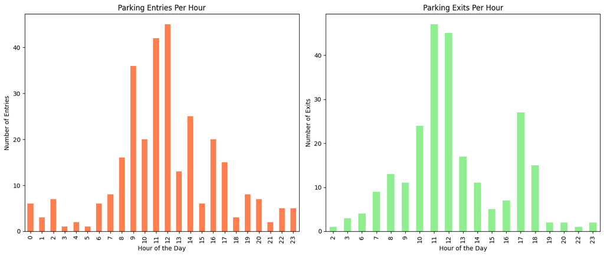

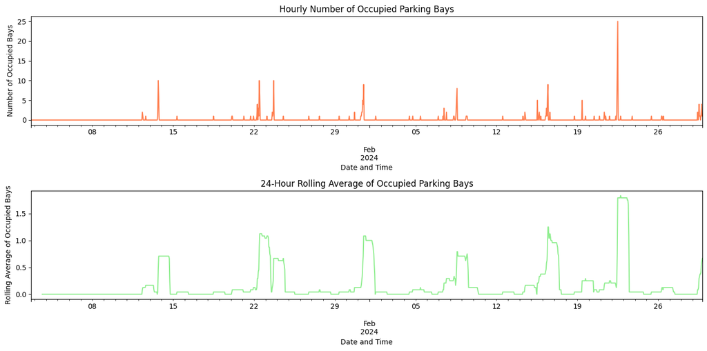

```python
import pandas as pd
import pytz
import matplotlib.pyplot as plt

# Load the dataset
file_path = r'C:\Users\ssgul\OneDrive\Documents\GitHub\MOP-Code\Playground\sgulluoglu\on-street-parking-bay-sensors.csv'
df = pd.read_csv(file_path)

# List the column names
print("Column Names:")
print(df.columns.tolist())

# Define the timezone conversion function
def convert_utc_to_melbourne(utc_time_str):
    utc_zone = pytz.utc
    melbourne_zone = pytz.timezone('Australia/Melbourne')

    # Convert the string to a datetime object
    utc_time = pd.to_datetime(utc_time_str, utc=True)

    # Convert to Melbourne time
    melbourne_time = utc_time.tz_convert(melbourne_zone)
    return melbourne_time

# List of columns to convert
columns_to_convert = ['Lastupdated', 'Status_Timestamp']

# Convert the specified columns
for column in columns_to_convert:
    if column in df.columns:
        df[column] = df[column].apply(lambda x: convert_utc_to_melbourne(x) if pd.notnull(x) else x)
        print(f"Updated Column: {column}")
    else:
        print(f"Column '{column}' not found in the data")

# Filter data to include only rows up to August 2024
df = df[(df['Status_Timestamp'].dt.year == 2024) & (df['Status_Timestamp'].dt.month <= 2)]

# List missing values
print("\nMissing Values:")
print(df.isnull().sum())

# Fill missing values with values from other columns/rows
df.fillna(method='ffill', inplace=True)  # Forward fill
df.fillna(method='bfill', inplace=True)  # Backward fill

# Recheck missing values
print("\nMissing Values After Filling:")
print(df.isnull().sum())

# Calculate the parking time
if 'Lastupdated' in df.columns and 'Status_Timestamp' in df.columns:
    df['parking_time'] = (df['Lastupdated'] - df['Status_Timestamp']).dt.total_seconds() / 60  # Convert to minutes
    print("\nDataFrame with Parking Time:")
    print(df[['Lastupdated', 'Status_Timestamp', 'parking_time']].head())
else:
    print("Required columns for parking time calculation are missing.")

# Set 'Status_Timestamp' as the index and ensure it is in datetime format
df.set_index('Status_Timestamp', inplace=True)

# Resample data to hourly frequency
df_hourly = df.resample('H').agg({
    'Status_Description': lambda x: (x == 'Present').sum(),  # Count 'Occupied' status
    'parking_time': 'mean'  # Average parking time
})

# Calculate rolling averages with a 24-hour window
df_hourly['Occupied_Rolling_Avg'] = df_hourly['Status_Description'].rolling(window=24).mean()

# Extract the hour from Status_Timestamp for histogram plotting
df['Hour'] = df.index.hour

# Assuming 'Status_Description' has values 'Occupied' and 'Vacant' for entries and exits
entries_per_hour = df[df['Status_Description'] == 'Unoccupied'].groupby('Hour').size()
exits_per_hour = df[df['Status_Description'] == 'Present'].groupby('Hour').size()

# Plot histograms for Entries and Exits
plt.figure(figsize=(14, 6))

# Plot for Entries
plt.subplot(1, 2, 1)
entries_per_hour.plot(kind='bar', color='coral')
plt.title('Parking Entries Per Hour')
plt.xlabel('Hour of the Day')
plt.ylabel('Number of Entries')

# Plot for Exits
plt.subplot(1, 2, 2)
exits_per_hour.plot(kind='bar', color='lightgreen')
plt.title('Parking Exits Per Hour')
plt.xlabel('Hour of the Day')
plt.ylabel('Number of Exits')

plt.tight_layout()
plt.show()

# Plot rolling averages
plt.figure(figsize=(14, 7))

# Plot number of occupied statuses per hour
plt.subplot(2, 1, 1)
df_hourly['Status_Description'].plot(title='Hourly Number of Occupied Parking Bays', color='coral')
plt.xlabel('Date and Time')
plt.ylabel('Number of Occupied Bays')

# Plot rolling average of occupied statuses
plt.subplot(2, 1, 2)
df_hourly['Occupied_Rolling_Avg'].plot(title='24-Hour Rolling Average of Occupied Parking Bays', color='lightgreen')
plt.xlabel('Date and Time')
plt.ylabel('Rolling Average of Occupied Bays')

plt.tight_layout()
plt.show()
```

### 4.6.Parking Entry Exit Analysis & Visualization

This code processes parking data to analyze trends. It converts timestamps to Melbourne time, filters February 2024 data, fills missing values, and calculates parking time in minutes. Data is resampled hourly, rolling averages are computed for occupied bays, and parking entries/exits are analyzed. Visualizations include line graphs for hourly trends and rolling averages, revealing peak usage periods and behavioral patterns.

```
Column Names:
['Lastupdated', 'Status_Timestamp', 'Zone_Number', 'Status_Description', 'KerbsideID', 'Location']
Updated Column: Lastupdated
Updated Column: Status_Timestamp

Missing Values:
Lastupdated            0
Status_Timestamp       0
Zone_Number           51
Status_Description     0
KerbsideID             0
Location               0
dtype: int64

Missing Values After Filling:
Lastupdated           0
Status_Timestamp      0
Zone_Number           0
Status_Description    0
KerbsideID            0
Location              0
dtype: int64

DataFrame with Parking Time:
                  Lastupdated          Status_Timestamp  parking_time
924 2024-02-08 14:45:34+11:00 2024-02-07 11:41:48+11:00   1623.766667
925 2024-02-08 14:45:34+11:00 2024-02-07 11:37:42+11:00   1627.866667
926 2024-02-08 14:45:34+11:00 2024-02-05 10:05:52+11:00   4599.700000
927 2024-02-08 14:45:34+11:00 2024-02-08 13:43:55+11:00     61.650000
928 2024-02-08 14:45:34+11:00 2024-02-08 08:06:24+11:00    399.166667
```

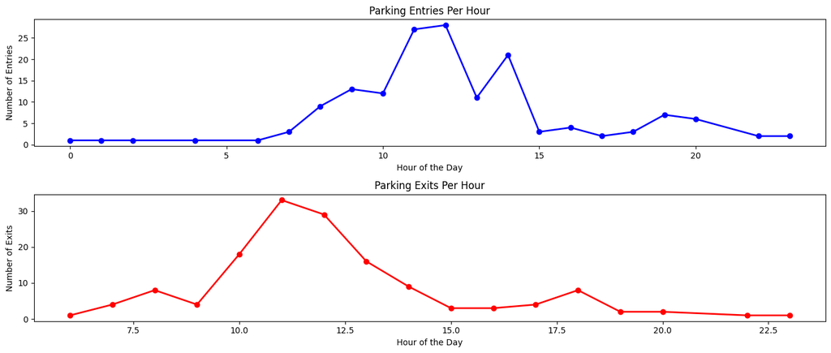

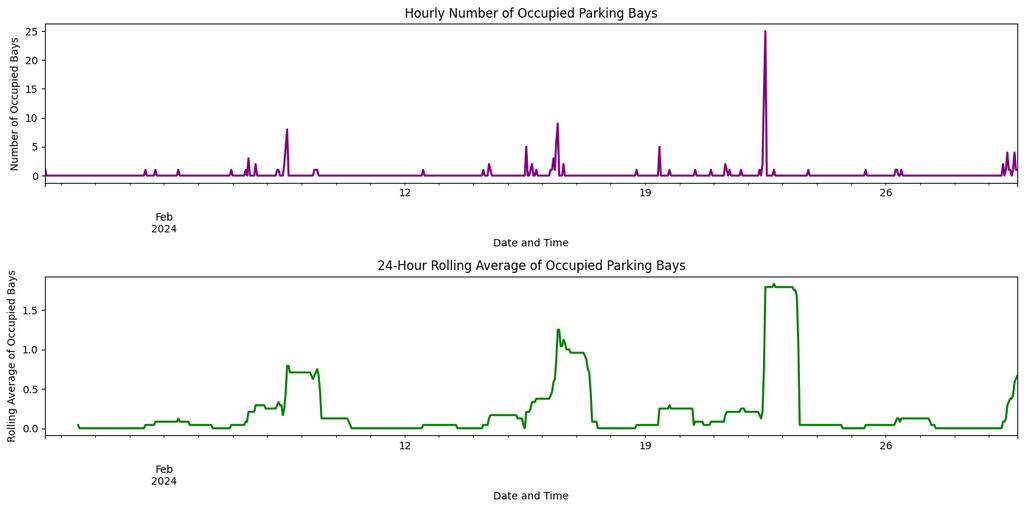

```python
import pandas as pd
import pytz
import matplotlib.pyplot as plt

# Load the dataset
file_path = r'C:\Users\ssgul\OneDrive\Documents\GitHub\MOP-Code\Playground\sgulluoglu\on-street-parking-bay-sensors.csv'
df = pd.read_csv(file_path)

# List the column names
print("Column Names:")
print(df.columns.tolist())

# Define the timezone conversion function
def convert_utc_to_melbourne(utc_time_str):
    utc_zone = pytz.utc
    melbourne_zone = pytz.timezone('Australia/Melbourne')

    # Convert the string to a datetime object
    utc_time = pd.to_datetime(utc_time_str, utc=True)

    # Convert to Melbourne time
    melbourne_time = utc_time.tz_convert(melbourne_zone)
    return melbourne_time

# List of columns to convert
columns_to_convert = ['Lastupdated', 'Status_Timestamp']

# Convert the specified columns
for column in columns_to_convert:
    if column in df.columns:
        df[column] = df[column].apply(lambda x: convert_utc_to_melbourne(x) if pd.notnull(x) else x)
        print(f"Updated Column: {column}")
    else:
        print(f"Column '{column}' not found in the data")

# Filter data to include only rows in Feb 2024
df = df[(df['Status_Timestamp'].dt.year == 2024) & (df['Status_Timestamp'].dt.month == 2)]

# List missing values
print("\nMissing Values:")
print(df.isnull().sum())

# Fill missing values with values from other columns/rows
df.fillna(method='ffill', inplace=True)  # Forward fill
df.fillna(method='bfill', inplace=True)  # Backward fill

# Recheck missing values
print("\nMissing Values After Filling:")
print(df.isnull().sum())

# Calculate the parking time
if 'Lastupdated' in df.columns and 'Status_Timestamp' in df.columns:
    df['parking_time'] = (df['Lastupdated'] - df['Status_Timestamp']).dt.total_seconds() / 60  # Convert to minutes
    print("\nDataFrame with Parking Time:")
    print(df[['Lastupdated', 'Status_Timestamp', 'parking_time']].head())
else:
    print("Required columns for parking time calculation are missing.")

# Set 'Status_Timestamp' as the index and ensure it is in datetime format
df.set_index('Status_Timestamp', inplace=True)

# Resample data to hourly frequency
df_hourly = df.resample('H').agg({
    'Status_Description': lambda x: (x == 'Present').sum(),  # Count 'Occupied' status
    'parking_time': 'mean'  # Average parking time
})

# Calculate rolling averages with a 24-hour window
df_hourly['Occupied_Rolling_Avg'] = df_hourly['Status_Description'].rolling(window=24).mean()

# Extract the hour from Status_Timestamp for histogram plotting
df['Hour'] = df.index.hour

# Calculate hourly parking entries and exits
entries_per_hour = df[df['Status_Description'] == 'Unoccupied'].groupby('Hour').size()
exits_per_hour = df[df['Status_Description'] == 'Present'].groupby('Hour').size()

# Plot line graphs for Entries and Exits over time
plt.figure(figsize=(14, 6))

# Plot for Entries over time
plt.subplot(2, 1, 1)
entries_per_hour.plot(kind='line', color='blue', marker='o', linestyle='-', linewidth=2)
plt.title('Parking Entries Per Hour')
plt.xlabel('Hour of the Day')
plt.ylabel('Number of Entries')

# Plot for Exits over time
plt.subplot(2, 1, 2)
exits_per_hour.plot(kind='line', color='red', marker='o', linestyle='-', linewidth=2)
plt.title('Parking Exits Per Hour')
plt.xlabel('Hour of the Day')
plt.ylabel('Number of Exits')

plt.tight_layout()
plt.show()

# Plot rolling averages using line graph
plt.figure(figsize=(14, 7))

# Plot number of occupied statuses per hour
plt.subplot(2, 1, 1)
df_hourly['Status_Description'].plot(kind='line', color='purple', linestyle='-', linewidth=2)
plt.title('Hourly Number of Occupied Parking Bays')
plt.xlabel('Date and Time')
plt.ylabel('Number of Occupied Bays')

# Plot rolling average of occupied statuses
plt.subplot(2, 1, 2)
df_hourly['Occupied_Rolling_Avg'].plot(kind='line', color='green', linestyle='-', linewidth=2)
plt.title('24-Hour Rolling Average of Occupied Parking Bays')
plt.xlabel('Date and Time')
plt.ylabel('Rolling Average of Occupied Bays')

plt.tight_layout()
plt.show()
```

### 4.7. Parking Behaviour Analysis

2024 Montly Parking Details - Graphs - January to August - averages of each month - annual analysis

```
Column Names:
['Lastupdated', 'Status_Timestamp', 'Zone_Number', 'Status_Description', 'KerbsideID', 'Location']
Updated Column: Lastupdated
Updated Column: Status_Timestamp

Missing Values:
Lastupdated             0
Status_Timestamp        0
Zone_Number           345
Status_Description      0
KerbsideID              0
Location                0
dtype: int64

Missing Values After Filling:
Lastupdated           0
Status_Timestamp      0
Zone_Number           0
Status_Description    0
KerbsideID            0
Location              0
dtype: int64

DataFrame with Parking Time:
                  Lastupdated          Status_Timestamp  parking_time
764 2024-01-22 12:45:34+11:00 2024-01-20 02:10:46+11:00   3514.800000
765 2024-01-22 12:45:34+11:00 2024-01-13 16:11:01+11:00  12754.550000
766 2024-01-22 12:45:34+11:00 2024-01-13 18:51:45+11:00  12593.816667
767 2024-01-22 12:45:34+11:00 2024-01-13 17:02:07+11:00  12703.450000
768 2024-01-22 12:45:34+11:00 2024-01-13 17:41:19+11:00  12664.250000
```

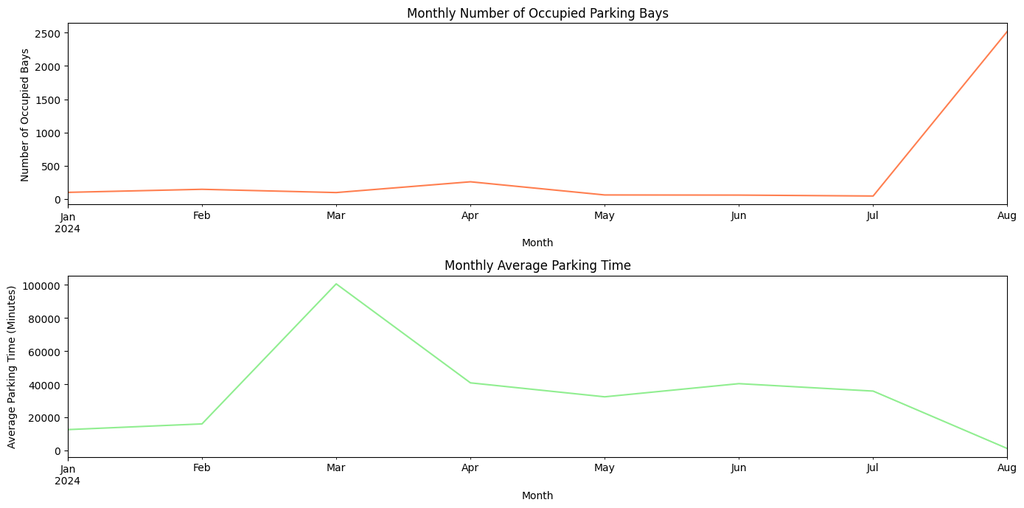

```python
import pandas as pd
import pytz
import matplotlib.pyplot as plt

# Load the dataset
file_path = r'C:\Users\ssgul\OneDrive\Documents\GitHub\MOP-Code\Playground\sgulluoglu\on-street-parking-bay-sensors.csv'
df = pd.read_csv(file_path)

# List the column names
print("Column Names:")
print(df.columns.tolist())

# Define the timezone conversion function
def convert_utc_to_melbourne(utc_time_str):
    utc_zone = pytz.utc
    melbourne_zone = pytz.timezone('Australia/Melbourne')

    # Convert the string to a datetime object
    utc_time = pd.to_datetime(utc_time_str, utc=True)

    # Convert to Melbourne time
    melbourne_time = utc_time.tz_convert(melbourne_zone)
    return melbourne_time

# List of columns to convert
columns_to_convert = ['Lastupdated', 'Status_Timestamp']

# Convert the specified columns
for column in columns_to_convert:
    if column in df.columns:
        df[column] = df[column].apply(lambda x: convert_utc_to_melbourne(x) if pd.notnull(x) else x)
        print(f"Updated Column: {column}")
    else:
        print(f"Column '{column}' not found in the data")

# Filter data to include only rows from January to August 2024
df = df[(df['Status_Timestamp'].dt.year == 2024) & (df['Status_Timestamp'].dt.month <= 8)]

# List missing values
print("\nMissing Values:")
print(df.isnull().sum())

# Fill missing values with values from other columns/rows
df.fillna(method='ffill', inplace=True)  # Forward fill
df.fillna(method='bfill', inplace=True)  # Backward fill

# Recheck missing values
print("\nMissing Values After Filling:")
print(df.isnull().sum())

# Calculate the parking time
if 'Lastupdated' in df.columns and 'Status_Timestamp' in df.columns:
    df['parking_time'] = (df['Lastupdated'] - df['Status_Timestamp']).dt.total_seconds() / 60  # Convert to minutes
    print("\nDataFrame with Parking Time:")
    print(df[['Lastupdated', 'Status_Timestamp', 'parking_time']].head())
else:
    print("Required columns for parking time calculation are missing.")

# Set 'Status_Timestamp' as the index and ensure it is in datetime format
df.set_index('Status_Timestamp', inplace=True)

# Resample data to monthly frequency to find the average
df_monthly = df.resample('M').agg({
    'Status_Description': lambda x: (x == 'Present').sum(),  # Count 'Occupied' status
    'parking_time': 'mean'  # Average parking time
})

# Plot monthly averages
plt.figure(figsize=(14, 7))

# Plot number of occupied statuses per month
plt.subplot(2, 1, 1)
df_monthly['Status_Description'].plot(title='Monthly Number of Occupied Parking Bays', color='coral')
plt.xlabel('Month')
plt.ylabel('Number of Occupied Bays')

# Plot average parking time per month
plt.subplot(2, 1, 2)
df_monthly['parking_time'].plot(title='Monthly Average Parking Time', color='lightgreen')
plt.xlabel('Month')
plt.ylabel('Average Parking Time (Minutes)')

plt.tight_layout()
plt.show()
```

### 4.8. Correlation Analysis of Numeric Parking Dataset Features

This code performs a correlation analysis on numeric columns of a parking dataset. Time columns are converted to datetime, and Status_Description values are mapped to integers for analysis. Parking time in minutes is calculated, and non-numeric columns are excluded to create a numeric-only subset. A Pearson correlation matrix is computed to identify relationships between features. The results are visualized using a heatmap, highlighting feature correlations, and printed as a table for detailed inspection. This analysis aids in understanding key interactions between variables.

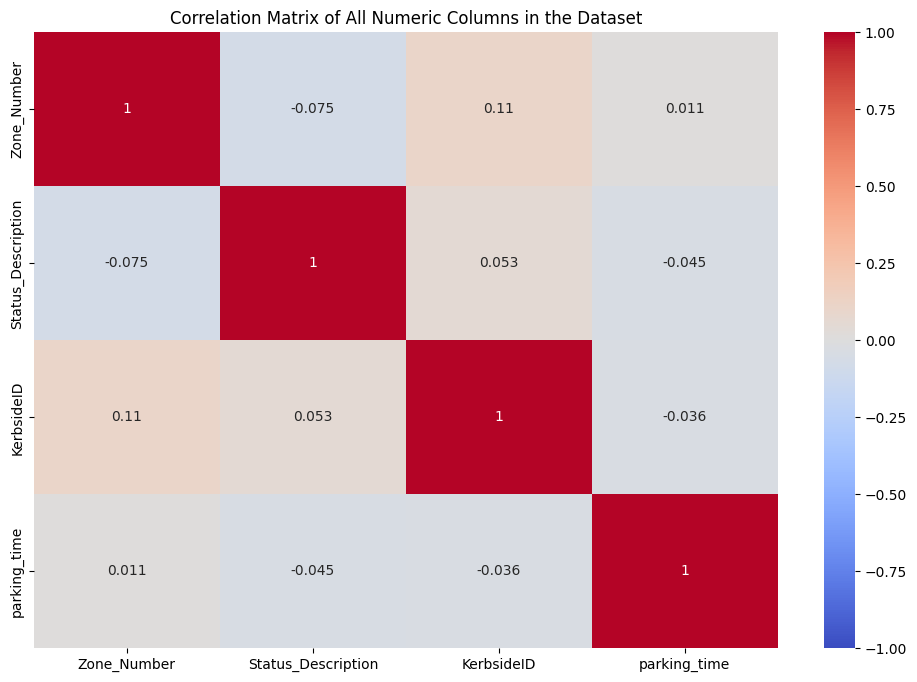

```
Correlation Matrix Table:
                    Zone_Number  Status_Description  KerbsideID  parking_time
Zone_Number            1.000000           -0.075150    0.106434      0.010869
Status_Description    -0.075150            1.000000    0.053272     -0.045223
KerbsideID             0.106434            0.053272    1.000000     -0.036208
parking_time           0.010869           -0.045223   -0.036208      1.000000
```

```python
import pandas as pd
import seaborn as sns
import matplotlib.pyplot as plt

# Load the dataset (Replace with your actual dataset path)
file_path = r'C:\Users\ssgul\OneDrive\Documents\GitHub\MOP-Code\Playground\sgulluoglu\on-street-parking-bay-sensors.csv'
df = pd.read_csv(file_path)

# Convert relevant time columns to datetime (example)
df['Lastupdated'] = pd.to_datetime(df['Lastupdated'], utc=True)
df['Status_Timestamp'] = pd.to_datetime(df['Status_Timestamp'], utc=True)

# Replace 'Status_Description' field values
df['Status_Description'] = df['Status_Description'].map({'Present': 1, 'Unoccupied': 0})

# Example: Calculate the parking time in minutes
df['parking_time'] = (df['Lastupdated'] - df['Status_Timestamp']).dt.total_seconds() / 60

# Drop columns with non-numeric data or convert them to numeric as needed
# Keep the 'Status_Description' since it's now numeric
df_numeric = df.select_dtypes(include=[float, int])

# Include 'Status_Description' explicitly in case it's not picked up automatically
if 'Status_Description' in df.columns:
    df_numeric['Status_Description'] = df['Status_Description']

# Calculate the correlation matrix
corr_matrix = df_numeric.corr(method='pearson')

# Plot the correlation matrix using a heatmap
plt.figure(figsize=(12, 8))
sns.heatmap(corr_matrix, annot=True, cmap='coolwarm', vmin=-1, vmax=1)
plt.title('Correlation Matrix of All Numeric Columns in the Dataset')
plt.show()

# Print the correlation matrix as a table
print("\nCorrelation Matrix Table:")
print(corr_matrix)
```

### 4.9. Correlation Analysis Between predefined columns

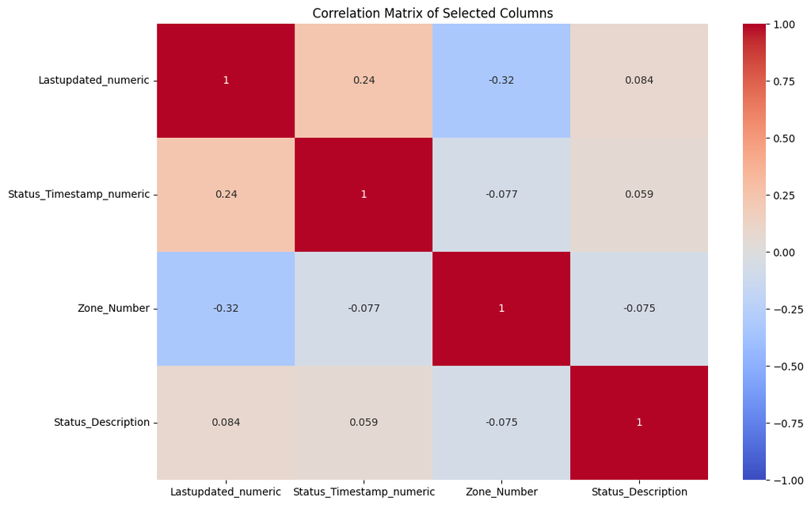

```
Correlation Matrix Table:
                          Lastupdated_numeric  Status_Timestamp_numeric  \
Lastupdated_numeric                  1.000000                  0.236253
Status_Timestamp_numeric             0.236253                  1.000000
Zone_Number                         -0.322617                 -0.077418
Status_Description                   0.084447                  0.058615

                          Zone_Number  Status_Description
Lastupdated_numeric         -0.322617            0.084447
Status_Timestamp_numeric    -0.077418            0.058615
Zone_Number                  1.000000           -0.075150
Status_Description          -0.075150            1.000000
```

```python
import pandas as pd
import seaborn as sns
import matplotlib.pyplot as plt

# Load the dataset (Replace with your actual dataset path)
file_path = r'C:\Users\ssgul\OneDrive\Documents\GitHub\MOP-Code\Playground\sgulluoglu\on-street-parking-bay-sensors.csv'
df = pd.read_csv(file_path)

# Convert relevant time columns to datetime
df['Lastupdated'] = pd.to_datetime(df['Lastupdated'], utc=True)
df['Status_Timestamp'] = pd.to_datetime(df['Status_Timestamp'], utc=True)

# Replace 'Status_Description' field values with 1 for 'Present' and 0 for 'Unoccupied'
df['Status_Description'] = df['Status_Description'].map({'Present': 1, 'Unoccupied': 0})

# Convert datetime columns to numeric (e.g., timestamps in seconds) for correlation analysis
df['Lastupdated_numeric'] = df['Lastupdated'].apply(lambda x: x.timestamp())
df['Status_Timestamp_numeric'] = df['Status_Timestamp'].apply(lambda x: x.timestamp())

# Select relevant variables for correlation analysis
corr_columns = ['Lastupdated_numeric', 'Status_Timestamp_numeric', 'Zone_Number', 'Status_Description']
corr_data = df[corr_columns]

# Calculate the correlation matrix
corr_matrix = corr_data.corr(method='pearson')

# Plot the correlation matrix using a heatmap
plt.figure(figsize=(12, 8))
sns.heatmap(corr_matrix, annot=True, cmap='coolwarm', vmin=-1, vmax=1)
plt.title('Correlation Matrix of Selected Columns')
plt.show()

# Print the correlation matrix as a table
print("\nCorrelation Matrix Table:")
print(corr_matrix)
```

Interpretation for Highly Correlated Results

Lastupdated_numeric and Zone_Number: Correlation Coefficient: -0.322617 Interpretation: This moderate negative correlation suggests that there is an inverse relationship between the Lastupdated time and the Zone_Number. As the Zone_Number increases, the Lastupdated time tends to decrease (or is earlier). This might imply that certain zones are more frequently updated earlier than others, potentially due to differing traffic patterns or update priorities across different zones. Lastupdated_numeric and Status_Timestamp_numeric: Correlation Coefficient: 0.236253 Interpretation: While this is not a strong correlation, the positive relationship indicates that as the Status_Timestamp increases (i.e., later times), the Lastupdated time also tends to increase, though the relationship is weak. This makes sense since updates are likely to occur around the same time as status changes, but the relatively low correlation suggests there might be variability in how promptly updates follow status changes.

### 4.10. Parking prediction analysis for 2025, January to August

```
Column Names:
['Lastupdated', 'Status_Timestamp', 'Zone_Number', 'Status_Description', 'KerbsideID', 'Location']
Updated Column: Lastupdated
Updated Column: Status_Timestamp

Missing Values:
Lastupdated             0
Status_Timestamp        0
Zone_Number           499
Status_Description      0
KerbsideID              0
Location                0
dtype: int64

Missing Values After Filling:
Lastupdated           0
Status_Timestamp      0
Zone_Number           0
Status_Description    0
KerbsideID            0
Location              0
dtype: int64

DataFrame with Parking Time:
                Lastupdated          Status_Timestamp  parking_time
0 2023-12-14 15:45:34+11:00 2023-12-14 14:41:25+11:00     64.150000
1 2023-12-14 15:45:34+11:00 2023-12-13 17:21:58+11:00   1343.600000
2 2023-12-15 10:45:34+11:00 2023-12-15 10:35:02+11:00     10.533333
3 2023-12-15 10:45:34+11:00 2023-12-15 09:39:46+11:00     65.800000
4 2023-12-18 15:45:34+11:00 2023-12-18 10:47:54+11:00    297.666667
```

[output not shown]

[output cut: 57 more lines]

```
14/14 - 0s - 3ms/step - loss: 2.7766e-04
14/14 - 0s - 3ms/step - loss: 2.5907e-04
14/14 - 0s - 3ms/step - loss: 2.6257e-04
1/1 ━━━━━━━━━━━━━━━━━━━━ 0s 155ms/step
1/1 ━━━━━━━━━━━━━━━━━━━━ 0s 248ms/step
Train Score: 40.21 RMSE
Test Score: 112.93 RMSE
1/1 ━━━━━━━━━━━━━━━━━━━━ 0s 45ms/step
1/1 ━━━━━━━━━━━━━━━━━━━━ 0s 47ms/step
1/1 ━━━━━━━━━━━━━━━━━━━━ 0s 43ms/step
1/1 ━━━━━━━━━━━━━━━━━━━━ 0s 40ms/step
1/1 ━━━━━━━━━━━━━━━━━━━━ 0s 38ms/step
1/1 ━━━━━━━━━━━━━━━━━━━━ 0s 49ms/step
1/1 ━━━━━━━━━━━━━━━━━━━━ 0s 49ms/step
1/1 ━━━━━━━━━━━━━━━━━━━━ 0s 47ms/step
```

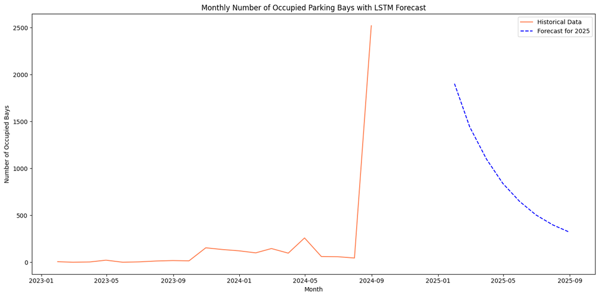

```python
import pandas as pd
import pytz
import numpy as np
import matplotlib.pyplot as plt
from sklearn.preprocessing import MinMaxScaler
from sklearn.metrics import mean_squared_error
from tensorflow.keras.models import Sequential
from tensorflow.keras.layers import Dense, LSTM

# Load the dataset
file_path = r'C:\Users\ssgul\OneDrive\Documents\GitHub\MOP-Code\Playground\sgulluoglu\on-street-parking-bay-sensors.csv'
df = pd.read_csv(file_path)

# List the column names
print("Column Names:")
print(df.columns.tolist())

# Define the timezone conversion function
def convert_utc_to_melbourne(utc_time_str):
    melbourne_zone = pytz.timezone('Australia/Melbourne')
    utc_time = pd.to_datetime(utc_time_str, utc=True)
    melbourne_time = utc_time.tz_convert(melbourne_zone)
    return melbourne_time

# List of columns to convert
columns_to_convert = ['Lastupdated', 'Status_Timestamp']

# Convert the specified columns
for column in columns_to_convert:
    if column in df.columns:
        df[column] = df[column].apply(lambda x: convert_utc_to_melbourne(x) if pd.notnull(x) else x)
        print(f"Updated Column: {column}")
    else:
        print(f"Column '{column}' not found in the data")

# Filter data to include only rows from January 2023 to August 2024
df = df[(df['Status_Timestamp'] >= '2023-01-01') & (df['Status_Timestamp'] <= '2024-08-31')]

# List missing values
print("\nMissing Values:")
print(df.isnull().sum())

# Fill missing values with values from other columns/rows
df.ffill(inplace=True)  # Forward fill
df.bfill(inplace=True)  # Backward fill

# Recheck missing values
print("\nMissing Values After Filling:")
print(df.isnull().sum())

# Calculate the parking time
if 'Lastupdated' in df.columns and 'Status_Timestamp' in df.columns:
    df['parking_time'] = (df['Lastupdated'] - df['Status_Timestamp']).dt.total_seconds() / 60  # Convert to minutes
    print("\nDataFrame with Parking Time:")
    print(df[['Lastupdated', 'Status_Timestamp', 'parking_time']].head())
else:
    print("Required columns for parking time calculation are missing.")

# Set 'Status_Timestamp' as the index and ensure it is in datetime format
df.set_index('Status_Timestamp', inplace=True)

# Resample data to monthly frequency to find the average
df_monthly = df.resample('M').agg({
    'Status_Description': lambda x: (x == 'Present').sum(),  # Count 'Present' status
    'parking_time': 'mean'  # Average parking time
})

# Normalize the data
scaler = MinMaxScaler(feature_range=(0, 1))
df_monthly_scaled = scaler.fit_transform(df_monthly[['Status_Description']])

# Function to create dataset matrix
def create_dataset(dataset, look_back=1):
    X, Y = [], []
    for i in range(len(dataset) - look_back - 1):
        a = dataset[i:(i + look_back), 0]
        X.append(a)
        Y.append(dataset[i + look_back, 0])
    return np.array(X), np.array(Y)

# Prepare the dataset for LSTM
look_back = 1
X, Y = create_dataset(df_monthly_scaled, look_back)

# Reshape input to be [samples, time steps, features]
X = np.reshape(X, (X.shape[0], 1, X.shape[1]))

# Split into train and test sets
train_size = int(len(X) * 0.8)
test_size = len(X) - train_size
X_train, X_test = X[0:train_size], X[train_size:len(X)]
Y_train, Y_test = Y[0:train_size], Y[train_size:len(Y)]

# Build LSTM Model
model = Sequential()
model.add(LSTM(100, input_shape=(1, look_back)))
model.add(Dense(1))
model.compile(loss='mean_squared_error', optimizer='adam')

# Train the model
model.fit(X_train, Y_train, epochs=100, batch_size=1, verbose=2)

# Make predictions
train_predict = model.predict(X_train)
test_predict = model.predict(X_test)

# Invert predictions to original scale
train_predict = scaler.inverse_transform(train_predict)
trainY = scaler.inverse_transform([Y_train])
test_predict = scaler.inverse_transform(test_predict)
testY = scaler.inverse_transform([Y_test])

# Calculate RMSE
train_score = np.sqrt(mean_squared_error(trainY[0], train_predict[:, 0]))
print(f'Train Score: {train_score:.2f} RMSE')
test_score = np.sqrt(mean_squared_error(testY[0], test_predict[:, 0]))
print(f'Test Score: {test_score:.2f} RMSE')

# Forecast for 8 months ahead (January to August 2025)
future_periods = 8
forecast = []
current_batch = df_monthly_scaled[-look_back:].reshape((1, 1, look_back))

for _ in range(future_periods):
    current_pred = model.predict(current_batch)[0]
    forecast.append(current_pred)
    current_batch = np.append(current_batch[:, :, 1:], [[current_pred]], axis=2)

# Invert forecast to original scale
forecast = scaler.inverse_transform(forecast)

# Create a date range for the forecast
forecast_index = pd.date_range(start='2025-01-01', periods=future_periods, freq='M')

# Plot historical and forecasted data
plt.figure(figsize=(14, 7))

# Plot number of occupied statuses per month with forecast
plt.plot(df_monthly.index, df_monthly['Status_Description'], label='Historical Data', color='coral')
plt.plot(forecast_index, forecast, label='Forecast for 2025', color='blue', linestyle='--')
plt.title('Monthly Number of Occupied Parking Bays with LSTM Forecast')
plt.xlabel('Month')
plt.ylabel('Number of Occupied Bays')
plt.legend()

plt.tight_layout()
plt.show()
```

### 4.12. Comparison- parking slots need for 2025 based on 2024. - Forecasting

This code forecasts parking occupancy trends using LSTM. It preprocesses parking data by converting timestamps to Melbourne time, filtering for January-August 2024, and calculating parking time. The data is resampled hourly, normalized, and structured for LSTM input. An LSTM model is trained on 80% of the data, and predictions are made for testing and future periods. The model forecasts hourly occupancy from January-August 2025, converting predictions back to original scale and aggregating monthly values. Results are visualized, comparing 2024 data to 2025 forecasts, and displayed in a summary table for clear insights into parking trends.

[output not shown]

[output cut: 5809 more lines]

[output not shown]

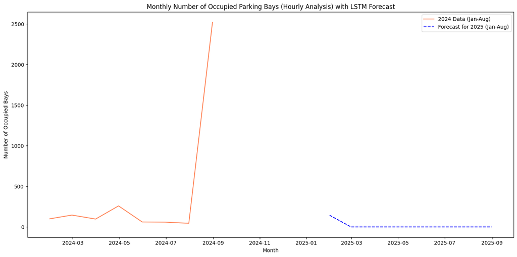

```
Forecasted and Actual Occupied Bays (Hourly Analysis) for January to August:
     Month  Forecasted Occupied Bays (2025)  Actual Occupied Bays (2024)
0  2025-01                       143.592389                          100
1  2025-02                         0.000000                          146
2  2025-03                         0.000000                           97
3  2025-04                         0.000000                          259
4  2025-05                         0.000000                           61
5  2025-06                         0.000000                           59
6  2025-07                         0.000000                           45
7  2025-08                         0.000000                         2521
```

```python
import pandas as pd
import pytz
import numpy as np
import matplotlib.pyplot as plt
from sklearn.preprocessing import MinMaxScaler
from sklearn.metrics import mean_squared_error
from tensorflow.keras.models import Sequential
from tensorflow.keras.layers import Dense, LSTM

# Load the dataset
file_path = r'C:\Users\ssgul\OneDrive\Documents\GitHub\MOP-Code\Playground\sgulluoglu\on-street-parking-bay-sensors.csv'
df = pd.read_csv(file_path)

# Define the timezone conversion function
def convert_utc_to_melbourne(utc_time_str):
    melbourne_zone = pytz.timezone('Australia/Melbourne')
    utc_time = pd.to_datetime(utc_time_str, utc=True)
    melbourne_time = utc_time.tz_convert(melbourne_zone)
    return melbourne_time

# List of columns to convert
columns_to_convert = ['Lastupdated', 'Status_Timestamp']

# Convert the specified columns
for column in columns_to_convert:
    if column in df.columns:
        df[column] = df[column].apply(lambda x: convert_utc_to_melbourne(x) if pd.notnull(x) else x)

# Filter data to include only rows from January 2024 to August 2024
df_2024 = df[(df['Status_Timestamp'] >= '2024-01-01') & (df['Status_Timestamp'] <= '2024-08-31')]

# Calculate the parking time
df_2024['parking_time'] = (df_2024['Lastupdated'] - df_2024['Status_Timestamp']).dt.total_seconds() / 60  # Convert to minutes

# Set 'Status_Timestamp' as the index and ensure it is in datetime format
df_2024.set_index('Status_Timestamp', inplace=True)

# Resample data to hourly frequency to find the average
df_hourly_2024 = df_2024.resample('H').agg({
    'Status_Description': lambda x: (x == 'Present').sum(),  # Count 'Present' status
    'parking_time': 'mean'  # Average parking time
})

# Replace negative results with zero
df_hourly_2024['Status_Description'] = df_hourly_2024['Status_Description'].clip(lower=0)

# Normalize the data
scaler = MinMaxScaler(feature_range=(0, 1))
df_hourly_scaled_2024 = scaler.fit_transform(df_hourly_2024[['Status_Description']])

# Function to create dataset matrix
def create_dataset(dataset, look_back=1):
    X, Y = [], []
    for i in range(len(dataset) - look_back - 1):
        a = dataset[i:(i + look_back), 0]
        X.append(a)
        Y.append(dataset[i + look_back, 0])
    return np.array(X), np.array(Y)

# Prepare the dataset for LSTM
look_back = 1
X, Y = create_dataset(df_hourly_scaled_2024, look_back)

# Reshape input to be [samples, time steps, features]
X = np.reshape(X, (X.shape[0], 1, X.shape[1]))

# Split into train and test sets
train_size = int(len(X) * 0.8)
test_size = len(X) - train_size
X_train, X_test = X[0:train_size], X[train_size:len(X)]
Y_train, Y_test = Y[0:train_size], Y[train_size:len(Y)]

# Build LSTM Model
model = Sequential()
model.add(LSTM(100, input_shape=(1, look_back)))
model.add(Dense(1))
model.compile(loss='mean_squared_error', optimizer='adam')

# Train the model
model.fit(X_train, Y_train, epochs=100, batch_size=1, verbose=2)

# Make predictions
train_predict = model.predict(X_train)
test_predict = model.predict(X_test)

# Invert predictions to original scale
train_predict = scaler.inverse_transform(train_predict)
trainY = scaler.inverse_transform([Y_train])
test_predict = scaler.inverse_transform(test_predict)
testY = scaler.inverse_transform([Y_test])

# Calculate RMSE
train_score = np.sqrt(mean_squared_error(trainY[0], train_predict[:, 0]))
print(f'Train Score: {train_score:.2f} RMSE')
test_score = np.sqrt(mean_squared_error(testY[0], test_predict[:, 0]))
print(f'Test Score: {test_score:.2f} RMSE')

# Forecast for 8 months ahead (January to August 2025)
future_periods = 8 * 30 * 24  # 8 months worth of hourly predictions
forecast = []
current_batch = df_hourly_scaled_2024[-look_back:].reshape((1, 1, look_back))

for _ in range(future_periods):
    current_pred = model.predict(current_batch)[0]
    forecast.append(current_pred)
    current_batch = np.append(current_batch[:, :, 1:], [[current_pred]], axis=2)

# Invert forecast to original scale
forecast = scaler.inverse_transform(forecast)

# Replace negative forecasted values with zero
forecast[forecast < 0] = 0

# Resample the forecast to monthly frequency
forecast_df = pd.DataFrame(forecast, index=pd.date_range(start='2025-01-01', periods=future_periods, freq='H'))
forecast_monthly = forecast_df.resample('M').sum()

# Plot historical and forecasted data
plt.figure(figsize=(14, 7))

# Plot number of occupied statuses per month with forecast
df_hourly_2024_monthly = df_hourly_2024['Status_Description'].resample('M').sum()
plt.plot(df_hourly_2024_monthly.index, df_hourly_2024_monthly, label='2024 Data (Jan-Aug)', color='coral')
plt.plot(forecast_monthly.index, forecast_monthly, label='Forecast for 2025 (Jan-Aug)', color='blue', linestyle='--')
plt.title('Monthly Number of Occupied Parking Bays (Hourly Analysis) with LSTM Forecast')
plt.xlabel('Month')
plt.ylabel('Number of Occupied Bays')
plt.legend()

plt.tight_layout()
plt.show()

# Display results in a table
forecast_table = pd.DataFrame({
    'Month': forecast_monthly.index.strftime('%Y-%m'),
    'Forecasted Occupied Bays (2025)': forecast_monthly.values.flatten(),
    'Actual Occupied Bays (2024)': df_hourly_2024_monthly.values
})
print("\nForecasted and Actual Occupied Bays (Hourly Analysis) for January to August:")
print(forecast_table)
```

### 4.13. Interpretation of the results.

Additional Features: Consider incorporating more features (e.g., day of the week, special events) to improve the forecasting model. Hyperparameter Tuning: Experiment with different LSTM architectures(Long Short-Term Memory (LSTM)) is a type of artificial recurrent neural network (RNN) architecture used in the field of deep learning.), learning rates, or epochs to potentially improve the model's performance. Cross-Validation: Implement cross-validation to ensure the model's stability and performance across different data splits.

```
Available parking slots and corresponding Kerbside IDs from 2024-08-01 to 2024-09-11:
                        KerbsideID  Available_Slots
Time_of_Day
00:00                [8642, 20589]                2
00:02               [21521, 25091]                2
00:04                      [20588]                1
00:05        [65122, 10727, 17832]                3
00:07                      [10884]                1
...                            ...              ...
23:48                      [24991]                1
23:52                      [57316]                1
23:55                      [57230]                1
23:58               [16763, 21532]                2
23:59                      [10865]                1

[482 rows x 2 columns]
```

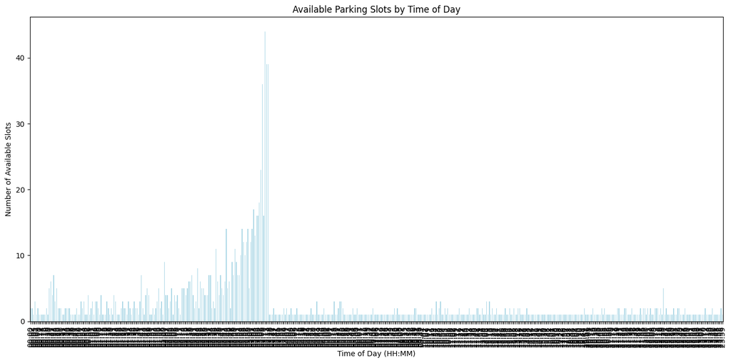

```python
import pandas as pd
import pytz
from datetime import datetime

# Load the dataset
file_path = r'C:\Users\ssgul\OneDrive\Documents\GitHub\MOP-Code\Playground\sgulluoglu\on-street-parking-bay-sensors.csv'
df = pd.read_csv(file_path)

# Convert relevant time columns to datetime
df['Lastupdated'] = pd.to_datetime(df['Lastupdated'], utc=True)
df['Status_Timestamp'] = pd.to_datetime(df['Status_Timestamp'], utc=True)

# Replace 'Status_Description' field values with 1 for 'Present' and 0 for 'Unoccupied'
df['Status_Description'] = df['Status_Description'].map({'Present': 1, 'Unoccupied': 0})

# Define the start date and current date in Melbourne timezone
melbourne_zone = pytz.timezone('Australia/Melbourne')
start_date = pd.to_datetime('2024-08-01', utc=True).tz_convert(melbourne_zone)
current_time = datetime.now(melbourne_zone)

# Filter data for the required date range
df_filtered = df[(df['Status_Timestamp'] >= start_date) & (df['Status_Timestamp'] <= current_time)]

# Extract the time of day (hour and minute) to group by
df_filtered['Time_of_Day'] = df_filtered['Status_Timestamp'].dt.strftime('%H:%M')

# Group data by time of day and check for available slots
available_slots_by_time = df_filtered[df_filtered['Status_Description'] == 0].groupby('Time_of_Day').agg({
    'KerbsideID': list,
    'Status_Description': 'count'
}).rename(columns={'Status_Description': 'Available_Slots'})

# Print the results
print(f"Available parking slots and corresponding Kerbside IDs from {start_date.strftime('%Y-%m-%d')} to {current_time.strftime('%Y-%m-%d')}:")
print(available_slots_by_time)

# Optionally, plot the results
plt.figure(figsize=(14, 7))
available_slots_by_time['Available_Slots'].plot(kind='bar', color='lightblue')
plt.title('Available Parking Slots by Time of Day')
plt.xlabel('Time of Day (HH:MM)')
plt.ylabel('Number of Available Slots')
plt.xticks(rotation=90)
plt.tight_layout()
plt.show()
```

### 4.14. Resampling and Time Series Forecasting Using LSTM

This code preprocesses parking data by converting timestamps to the Melbourne timezone and filtering data for a specific date range. It resamples parking slot availability by time of day and normalizes the data. Using a Long Short-Term Memory (LSTM) model, it forecasts parking slot availability for the same period in 2025. The historical and forecasted data are plotted for visualization, aiding in understanding parking trends. Additionally, forecast results are presented in a tabular format for further analysis.

```
480/480 - 2s - 5ms/step - loss: 0.0077
480/480 - 1s - 1ms/step - loss: 0.0053
480/480 - 1s - 1ms/step - loss: 0.0050
480/480 - 1s - 1ms/step - loss: 0.0046
480/480 - 1s - 1ms/step - loss: 0.0046
480/480 - 1s - 1ms/step - loss: 0.0047
480/480 - 1s - 1ms/step - loss: 0.0047
480/480 - 1s - 1ms/step - loss: 0.0047
480/480 - 1s - 1ms/step - loss: 0.0046
480/480 - 1s - 1ms/step - loss: 0.0046
480/480 - 1s - 1ms/step - loss: 0.0047
480/480 - 1s - 1ms/step - loss: 0.0045
480/480 - 1s - 1ms/step - loss: 0.0045
480/480 - 1s - 1ms/step - loss: 0.0047
480/480 - 1s - 1ms/step - loss: 0.0047
480/480 - 1s - 1ms/step - loss: 0.0044
480/480 - 1s - 1ms/step - loss: 0.0047
480/480 - 1s - 1ms/step - loss: 0.0045
480/480 - 1s - 1ms/step - loss: 0.0046
480/480 - 1s - 1ms/step - loss: 0.0045
480/480 - 1s - 1ms/step - loss: 0.0045
480/480 - 1s - 1ms/step - loss: 0.0044
480/480 - 1s - 1ms/step - loss: 0.0045
480/480 - 1s - 1ms/step - loss: 0.0045
480/480 - 1s - 1ms/step - loss: 0.0046
480/480 - 1s - 1ms/step - loss: 0.0043
480/480 - 1s - 1ms/step - loss: 0.0045
480/480 - 1s - 1ms/step - loss: 0.0045
480/480 - 1s - 1ms/step - loss: 0.0044
480/480 - 1s - 1ms/step - loss: 0.0044
480/480 - 1s - 1ms/step - loss: 0.0045
480/480 - 1s - 1ms/step - loss: 0.0044
480/480 - 1s - 1ms/step - loss: 0.0044
480/480 - 1s - 1ms/step - loss: 0.0044
480/480 - 1s - 1ms/step - loss: 0.0045
480/480 - 1s - 1ms/step - loss: 0.0044
480/480 - 1s - 1ms/step - loss: 0.0044
480/480 - 1s - 1ms/step - loss: 0.0044
480/480 - 1s - 1ms/step - loss: 0.0044
480/480 - 1s - 1ms/step - loss: 0.0042
```

[output cut: 527 more lines]

```
1/1 ━━━━━━━━━━━━━━━━━━━━ 0s 25ms/step
1/1 ━━━━━━━━━━━━━━━━━━━━ 0s 26ms/step
1/1 ━━━━━━━━━━━━━━━━━━━━ 0s 27ms/step
1/1 ━━━━━━━━━━━━━━━━━━━━ 0s 25ms/step
1/1 ━━━━━━━━━━━━━━━━━━━━ 0s 27ms/step
1/1 ━━━━━━━━━━━━━━━━━━━━ 0s 26ms/step
1/1 ━━━━━━━━━━━━━━━━━━━━ 0s 25ms/step
1/1 ━━━━━━━━━━━━━━━━━━━━ 0s 27ms/step
1/1 ━━━━━━━━━━━━━━━━━━━━ 0s 40ms/step
1/1 ━━━━━━━━━━━━━━━━━━━━ 0s 41ms/step
1/1 ━━━━━━━━━━━━━━━━━━━━ 0s 30ms/step
1/1 ━━━━━━━━━━━━━━━━━━━━ 0s 33ms/step
1/1 ━━━━━━━━━━━━━━━━━━━━ 0s 37ms/step
1/1 ━━━━━━━━━━━━━━━━━━━━ 0s 26ms/step
1/1 ━━━━━━━━━━━━━━━━━━━━ 0s 29ms/step
```

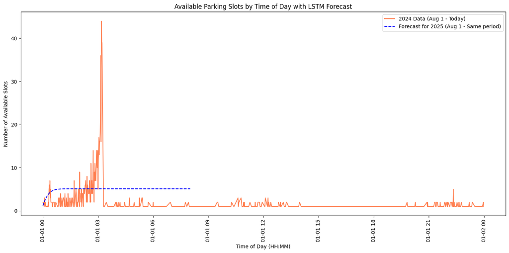

```
Forecasted Available Slots (Aug 1 - Same period in 2025):
    Time of Day  Forecasted Available Slots (2025)
0         00:00                           1.201797
1         00:02                           1.399664
2         00:04                           1.593084
3         00:05                           1.781590
4         00:07                           1.964766
..          ...                                ...
477       23:48                           5.114373
478       23:52                           5.114373
479       23:55                           5.114373
480       23:58                           5.114373
481       23:59                           5.114373

[482 rows x 2 columns]
```

```python
import pandas as pd
import pytz
from datetime import datetime
import numpy as np
import matplotlib.pyplot as plt
from sklearn.preprocessing import MinMaxScaler
from tensorflow.keras.models import Sequential
from tensorflow.keras.layers import Dense, LSTM

# Load the dataset
file_path = r'C:\Users\ssgul\OneDrive\Documents\GitHub\MOP-Code\Playground\sgulluoglu\on-street-parking-bay-sensors.csv'
df = pd.read_csv(file_path)

# Convert relevant time columns to datetime
df['Lastupdated'] = pd.to_datetime(df['Lastupdated'], utc=True)
df['Status_Timestamp'] = pd.to_datetime(df['Status_Timestamp'], utc=True)

# Replace 'Status_Description' field values with 1 for 'Present' and 0 for 'Unoccupied'
df['Status_Description'] = df['Status_Description'].map({'Present': 1, 'Unoccupied': 0})

# Define the start date and current date in Melbourne timezone
melbourne_zone = pytz.timezone('Australia/Melbourne')
start_date = pd.to_datetime('2024-08-01', utc=True).tz_convert(melbourne_zone)
current_time = datetime.now(melbourne_zone)

# Filter data for the required date range
df_filtered = df[(df['Status_Timestamp'] >= start_date) & (df['Status_Timestamp'] <= current_time)]

# Extract the time of day (hour and minute) to group by
df_filtered['Time_of_Day'] = df_filtered['Status_Timestamp'].dt.strftime('%H:%M')

# Group data by time of day and check for available slots
available_slots_by_time = df_filtered[df_filtered['Status_Description'] == 0].groupby('Time_of_Day').agg({
    'KerbsideID': list,
    'Status_Description': 'count'
}).rename(columns={'Status_Description': 'Available_Slots'})

# Ensure 'Time_of_Day' is sorted and set as an index
available_slots_by_time = available_slots_by_time.sort_index()

# Prepare data for time series forecasting
available_slots_by_time['Available_Slots'] = available_slots_by_time['Available_Slots'].astype(float)

# Normalize the data
scaler = MinMaxScaler(feature_range=(0, 1))
slots_scaled = scaler.fit_transform(available_slots_by_time[['Available_Slots']])

# Function to create dataset matrix
def create_dataset(dataset, look_back=1):
    X, Y = [], []
    for i in range(len(dataset) - look_back - 1):
        a = dataset[i:(i + look_back), 0]
        X.append(a)
        Y.append(dataset[i + look_back, 0])
    return np.array(X), np.array(Y)

# Prepare the dataset for LSTM
look_back = 1
X, Y = create_dataset(slots_scaled, look_back)

# Reshape input to be [samples, time steps, features]
X = np.reshape(X, (X.shape[0], 1, X.shape[1]))

# Build LSTM Model
model = Sequential()
model.add(LSTM(100, input_shape=(1, look_back)))
model.add(Dense(1))
model.compile(loss='mean_squared_error', optimizer='adam')

# Train the model
model.fit(X, Y, epochs=100, batch_size=1, verbose=2)

# Forecast for the corresponding time in 2025
future_periods = len(available_slots_by_time)  # Same number of time points as in the historical data
forecast = []
current_batch = slots_scaled[-look_back:].reshape((1, 1, look_back))

for _ in range(future_periods):
    current_pred = model.predict(current_batch)[0]
    forecast.append(current_pred)
    current_batch = np.append(current_batch[:, :, 1:], [[current_pred]], axis=2)

# Invert forecast to original scale
forecast = scaler.inverse_transform(forecast)

# Create a date range for the forecast in 2025
forecast_index = pd.date_range(start='2025-08-01', periods=future_periods, freq='T')

# Plot historical and forecasted data
plt.figure(figsize=(14, 7))

# Convert the index to a proper datetime format for plotting
available_slots_by_time.index = pd.to_datetime(available_slots_by_time.index, format='%H:%M')
forecast_index = pd.to_datetime(forecast_index.strftime('%H:%M'), format='%H:%M')

# Plot available slots per time of day with forecast
plt.plot(available_slots_by_time.index, available_slots_by_time['Available_Slots'], label='2024 Data (Aug 1 - Today)', color='coral')
plt.plot(forecast_index, forecast, label='Forecast for 2025 (Aug 1 - Same period)', color='blue', linestyle='--')
plt.title('Available Parking Slots by Time of Day with LSTM Forecast')
plt.xlabel('Time of Day (HH:MM)')
plt.ylabel('Number of Available Slots')
plt.xticks(rotation=90)
plt.legend()

plt.tight_layout()
plt.show()

# Display forecast results in a table
forecast_table = pd.DataFrame({
    'Time of Day': available_slots_by_time.index.strftime('%H:%M'),
    'Forecasted Available Slots (2025)': forecast.flatten(),
})
print("\nForecasted Available Slots (Aug 1 - Same period in 2025):")
print(forecast_table)
```

```
Column Names:
['lastupdated', 'status_timestamp', 'zone_number', 'status_description', 'kerbsideid', 'location']
Updated Column: lastupdated
Updated Column: status_timestamp

Missing Values:
lastupdated             0
status_timestamp        0
zone_number           328
status_description      0
kerbsideid              0
location                0
dtype: int64

Missing Values After Filling:
lastupdated           0
status_timestamp      0
zone_number           0
status_description    0
kerbsideid            0
location              0
dtype: int64

DataFrame with Parking Time:
                lastupdated          status_timestamp  parking_time
0 2023-12-14 15:45:34+11:00 2023-12-14 14:41:25+11:00     64.150000
1 2023-12-14 15:45:34+11:00 2023-12-13 17:21:58+11:00   1343.600000
2 2023-12-15 10:45:34+11:00 2023-12-15 10:35:02+11:00     10.533333
3 2023-12-15 10:45:34+11:00 2023-12-15 09:39:46+11:00     65.800000
4 2023-12-18 15:45:34+11:00 2023-12-18 10:47:54+11:00    297.666667
```

```
14/14 - 2s - 114ms/step - loss: 0.0924
14/14 - 0s - 4ms/step - loss: 0.0705
14/14 - 0s - 5ms/step - loss: 0.0547
14/14 - 0s - 5ms/step - loss: 0.0459
14/14 - 0s - 4ms/step - loss: 0.0392
14/14 - 0s - 4ms/step - loss: 0.0373
14/14 - 0s - 4ms/step - loss: 0.0350
14/14 - 0s - 4ms/step - loss: 0.0343
14/14 - 0s - 4ms/step - loss: 0.0328
14/14 - 0s - 4ms/step - loss: 0.0318
14/14 - 0s - 4ms/step - loss: 0.0306
14/14 - 0s - 4ms/step - loss: 0.0297
14/14 - 0s - 4ms/step - loss: 0.0288
14/14 - 0s - 4ms/step - loss: 0.0283
14/14 - 0s - 4ms/step - loss: 0.0275
14/14 - 0s - 4ms/step - loss: 0.0276
14/14 - 0s - 4ms/step - loss: 0.0264
14/14 - 0s - 4ms/step - loss: 0.0261
14/14 - 0s - 4ms/step - loss: 0.0256
14/14 - 0s - 3ms/step - loss: 0.0255
14/14 - 0s - 3ms/step - loss: 0.0252
14/14 - 0s - 4ms/step - loss: 0.0248
14/14 - 0s - 4ms/step - loss: 0.0246
14/14 - 0s - 4ms/step - loss: 0.0247
14/14 - 0s - 4ms/step - loss: 0.0244
14/14 - 0s - 3ms/step - loss: 0.0242
14/14 - 0s - 3ms/step - loss: 0.0240
14/14 - 0s - 4ms/step - loss: 0.0242
14/14 - 0s - 4ms/step - loss: 0.0240
14/14 - 0s - 3ms/step - loss: 0.0239
14/14 - 0s - 3ms/step - loss: 0.0239
14/14 - 0s - 3ms/step - loss: 0.0243
14/14 - 0s - 3ms/step - loss: 0.0240
14/14 - 0s - 4ms/step - loss: 0.0239
14/14 - 0s - 4ms/step - loss: 0.0239
14/14 - 0s - 4ms/step - loss: 0.0239
14/14 - 0s - 4ms/step - loss: 0.0239
14/14 - 0s - 3ms/step - loss: 0.0243
14/14 - 0s - 4ms/step - loss: 0.0243
14/14 - 0s - 4ms/step - loss: 0.0239
```

[output cut: 57 more lines]

```
14/14 - 0s - 3ms/step - loss: 0.0242
14/14 - 0s - 3ms/step - loss: 0.0239
14/14 - 0s - 4ms/step - loss: 0.0240
1/1 ━━━━━━━━━━━━━━━━━━━━ 0s 175ms/step
1/1 ━━━━━━━━━━━━━━━━━━━━ 0s 212ms/step
Train Score: 39.69 RMSE
Test Score: 114.17 RMSE
1/1 ━━━━━━━━━━━━━━━━━━━━ 0s 23ms/step
1/1 ━━━━━━━━━━━━━━━━━━━━ 0s 26ms/step
1/1 ━━━━━━━━━━━━━━━━━━━━ 0s 26ms/step
1/1 ━━━━━━━━━━━━━━━━━━━━ 0s 24ms/step
1/1 ━━━━━━━━━━━━━━━━━━━━ 0s 25ms/step
1/1 ━━━━━━━━━━━━━━━━━━━━ 0s 24ms/step
1/1 ━━━━━━━━━━━━━━━━━━━━ 0s 26ms/step
1/1 ━━━━━━━━━━━━━━━━━━━━ 0s 24ms/step
```

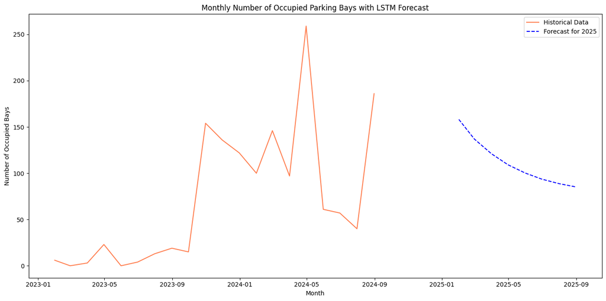

```python
import pandas as pd
import pytz
import numpy as np
import matplotlib.pyplot as plt
from sklearn.preprocessing import MinMaxScaler
from sklearn.metrics import mean_squared_error
from tensorflow.keras.models import Sequential
from tensorflow.keras.layers import Dense, LSTM
import requests

# API details
base_url = 'https://data.melbourne.vic.gov.au/api/explore/v2.1/catalog/datasets/'
dataset_id = 'on-street-parking-bay-sensors'

# Fetch the dataset from the API
url = f"{base_url}{dataset_id}/exports/csv"
df = pd.read_csv(url, delimiter=';')

# List the column names to verify them
print("Column Names:")
print(df.columns.tolist())

# Define the timezone conversion function
def convert_utc_to_melbourne(utc_time_str):
    melbourne_zone = pytz.timezone('Australia/Melbourne')
    utc_time = pd.to_datetime(utc_time_str, utc=True)
    melbourne_time = utc_time.tz_convert(melbourne_zone)
    return melbourne_time

# Convert the specified columns
columns_to_convert = ['lastupdated', 'status_timestamp']

for column in columns_to_convert:
    if column in df.columns:
        df[column] = df[column].apply(lambda x: convert_utc_to_melbourne(x) if pd.notnull(x) else x)
        print(f"Updated Column: {column}")
    else:
        print(f"Column '{column}' not found in the data")

# Filter data to include only rows from January 2023 to August 2024
df = df[(df['status_timestamp'] >= '2023-01-01') & (df['status_timestamp'] <= '2024-08-31')]

# List missing values
print("\nMissing Values:")
print(df.isnull().sum())

# Fill missing values with values from other columns/rows
df.ffill(inplace=True)  # Forward fill
df.bfill(inplace=True)  # Backward fill

# Recheck missing values
print("\nMissing Values After Filling:")
print(df.isnull().sum())

# Calculate the parking time
if 'lastupdated' in df.columns and 'status_timestamp' in df.columns:
    df['parking_time'] = (df['lastupdated'] - df['status_timestamp']).dt.total_seconds() / 60  # Convert to minutes
    print("\nDataFrame with Parking Time:")
    print(df[['lastupdated', 'status_timestamp', 'parking_time']].head())
else:
    print("Required columns for parking time calculation are missing.")

# Set 'status_timestamp' as the index and ensure it is in datetime format
df.set_index('status_timestamp', inplace=True)

# Resample data to monthly frequency to find the average
df_monthly = df.resample('M').agg({
    'status_description': lambda x: (x == 'Present').sum(),  # Count 'Present' status
    'parking_time': 'mean'  # Average parking time
})

# Normalize the data
scaler = MinMaxScaler(feature_range=(0, 1))
df_monthly_scaled = scaler.fit_transform(df_monthly[['status_description']])

# Function to create dataset matrix
def create_dataset(dataset, look_back=1):
    X, Y = [], []
    for i in range(len(dataset) - look_back - 1):
        a = dataset[i:(i + look_back), 0]
        X.append(a)
        Y.append(dataset[i + look_back, 0])
    return np.array(X), np.array(Y)

# Prepare the dataset for LSTM
look_back = 1
X, Y = create_dataset(df_monthly_scaled, look_back)

# Reshape input to be [samples, time steps, features]
X = np.reshape(X, (X.shape[0], 1, X.shape[1]))

# Split into train and test sets
train_size = int(len(X) * 0.8)
test_size = len(X) - train_size
X_train, X_test = X[0:train_size], X[train_size:len(X)]
Y_train, Y_test = Y[0:train_size], Y[train_size:len(Y)]

# Build LSTM Model
model = Sequential()
model.add(LSTM(100, input_shape=(1, look_back)))
model.add(Dense(1))
model.compile(loss='mean_squared_error', optimizer='adam')

# Train the model
model.fit(X_train, Y_train, epochs=100, batch_size=1, verbose=2)

# Make predictions
train_predict = model.predict(X_train)
test_predict = model.predict(X_test)

# Invert predictions to original scale
train_predict = scaler.inverse_transform(train_predict)
trainY = scaler.inverse_transform([Y_train])
test_predict = scaler.inverse_transform(test_predict)
testY = scaler.inverse_transform([Y_test])

# Calculate RMSE
train_score = np.sqrt(mean_squared_error(trainY[0], train_predict[:, 0]))
print(f'Train Score: {train_score:.2f} RMSE')
test_score = np.sqrt(mean_squared_error(testY[0], test_predict[:, 0]))
print(f'Test Score: {test_score:.2f} RMSE')

# Forecast for 8 months ahead (January to August 2025)
future_periods = 8
forecast = []
current_batch = df_monthly_scaled[-look_back:].reshape((1, 1, look_back))

for _ in range(future_periods):
    current_pred = model.predict(current_batch)[0]
    forecast.append(current_pred)
    current_batch = np.append(current_batch[:, :, 1:], [[current_pred]], axis=2)

# Invert forecast to original scale
forecast = scaler.inverse_transform(forecast)

# Create a date range for the forecast
forecast_index = pd.date_range(start='2025-01-01', periods=future_periods, freq='M')

# Plot historical and forecasted data
plt.figure(figsize=(14, 7))

# Plot number of occupied statuses per month with forecast
plt.plot(df_monthly.index, df_monthly['status_description'], label='Historical Data', color='coral')
plt.plot(forecast_index, forecast, label='Forecast for 2025', color='blue', linestyle='--')
plt.title('Monthly Number of Occupied Parking Bays with LSTM Forecast')
plt.xlabel('Month')
plt.ylabel('Number of Occupied Bays')
plt.legend()

plt.tight_layout()
plt.show()
```

### 4.15. Forecast future parking occupancy

This code predicts future parking occupancy by leveraging Melbourne's parking sensor data. It preprocesses timestamps into the Melbourne timezone and filters data for the last hour, focusing on occupied parking spots. Using an LSTM neural network, it trains a model with resampled data aggregated per minute. The model forecasts the number of occupied parking spots, allowing for the calculation of available spots. The system is evaluated using RMSE, providing insights into prediction accuracy and enabling better parking management strategies.

```python
import pandas as pd
import pytz
import numpy as np
import matplotlib.pyplot as plt
from sklearn.preprocessing import MinMaxScaler
from sklearn.metrics import mean_squared_error
from tensorflow.keras.models import Sequential
from tensorflow.keras.layers import Dense, LSTM
import requests
from datetime import datetime, timedelta

# API details
base_url = 'https://data.melbourne.vic.gov.au/api/explore/v2.1/catalog/datasets/'
dataset_id = 'on-street-parking-bay-sensors'

# Fetch the dataset from the API
url = f"{base_url}{dataset_id}/exports/csv"
df = pd.read_csv(url, delimiter=';')

# List the column names to verify them
print("Column Names:")
print(df.columns.tolist())

# Define the timezone conversion function
def convert_utc_to_melbourne(utc_time_str):
    melbourne_zone = pytz.timezone('Australia/Melbourne')
    utc_time = pd.to_datetime(utc_time_str, utc=True)
    melbourne_time = utc_time.tz_convert(melbourne_zone)
    return melbourne_time

# Convert the specified columns
columns_to_convert = ['lastupdated', 'status_timestamp']

for column in columns_to_convert:
    if column in df.columns:
        df[column] = df[column].apply(lambda x: convert_utc_to_melbourne(x) if pd.notnull(x) else x)
        print(f"Updated Column: {column}")
    else:
        print(f"Column '{column}' not found in the data")

# Filter data to include only rows from the last hour
one_hour_ago = pd.Timestamp.now(pytz.timezone('Australia/Melbourne')) - timedelta(hours=1)
df = df[df['status_timestamp'] >= one_hour_ago]

# Filter to include only rows where status_description is 'Present'
df_present = df[df['status_description'] == 'Present']

# Set 'status_timestamp' as the index and ensure it is in datetime format
df_present.set_index('status_timestamp', inplace=True)

# Resample data to a minute frequency to find the number of 'Present' statuses per kerbside ID
df_minutely = df_present.resample('T').agg({
    'kerbsideid': 'count'
})

# Calculate the total number of unique kerbside IDs in the dataset
total_kerbside_ids = df['kerbsideid'].nunique()

# Normalize the data
scaler = MinMaxScaler(feature_range=(0, 1))
df_minutely_scaled = scaler.fit_transform(df_minutely)

# Function to create dataset matrix
def create_dataset(dataset, look_back=1):
    X, Y = [], []
    for i in range(len(dataset) - look_back - 1):
        a = dataset[i:(i + look_back), 0]
        X.append(a)
        Y.append(dataset[i + look_back, 0])
    return np.array(X), np.array(Y)

# Prepare the dataset for LSTM
look_back = 1
X, Y = create_dataset(df_minutely_scaled, look_back)

# Reshape input to be [samples, time steps, features]
X = np.reshape(X, (X.shape[0], 1, X.shape[1]))

# Split into train and test sets
train_size = int(len(X) * 0.8)
test_size = len(X) - train_size
X_train, X_test = X[0:train_size], X[train_size:len(X)]
Y_train, Y_test = Y[0:train_size], Y[train_size:len(Y)]

# Build LSTM Model
model = Sequential()
model.add(LSTM(100, input_shape=(1, look_back)))
model.add(Dense(1))
model.compile(loss='mean_squared_error', optimizer='adam')

# Train the model
model.fit(X_train, Y_train, epochs=100, batch_size=1, verbose=2)

# Make predictions
train_predict = model.predict(X_train)
test_predict = model.predict(X_test)

# Invert predictions to original scale
train_predict = scaler.inverse_transform(train_predict)
trainY = scaler.inverse_transform([Y_train])
test_predict = scaler.inverse_transform(test_predict)
testY = scaler.inverse_transform([Y_test])

# Calculate RMSE
train_score = np.sqrt(mean_squared_error(trainY[0], train_predict[:, 0]))
print(f'Train Score: {train_score:.2f} RMSE')
test_score = np.sqrt(mean_squared_error(testY[0], test_predict[:, 0]))
print(f'Test Score: {test_score:.2f} RMSE')

# Forecast the occupied spots for the next minute
forecast_occupied = model.predict(X_test[-1].reshape(1, 1, look_back))
forecast_occupied = scaler.inverse_transform(forecast_occupied)

# Calculate available spots
forecast_available = total_kerbside_ids - forecast_occupied[0][0]

# Round to the nearest integer
forecast_available_rounded = round(forecast_available)

# List the forecasted available spots
print(f"\nForecasted Available Kerbside IDs (next minute): {forecast_available_rounded}")
```

```
Column Names:
['lastupdated', 'status_timestamp', 'zone_number', 'status_description', 'kerbsideid', 'location']
Updated Column: lastupdated
Updated Column: status_timestamp
```

```
43/43 - 2s - 43ms/step - loss: 0.1419
43/43 - 0s - 2ms/step - loss: 0.0531
43/43 - 0s - 2ms/step - loss: 0.0402
43/43 - 0s - 2ms/step - loss: 0.0386
43/43 - 0s - 2ms/step - loss: 0.0378
43/43 - 0s - 2ms/step - loss: 0.0382
43/43 - 0s - 2ms/step - loss: 0.0381
43/43 - 0s - 2ms/step - loss: 0.0375
43/43 - 0s - 2ms/step - loss: 0.0381
43/43 - 0s - 2ms/step - loss: 0.0379
43/43 - 0s - 2ms/step - loss: 0.0375
43/43 - 0s - 2ms/step - loss: 0.0382
43/43 - 0s - 2ms/step - loss: 0.0378
43/43 - 0s - 2ms/step - loss: 0.0376
43/43 - 0s - 2ms/step - loss: 0.0376
43/43 - 0s - 2ms/step - loss: 0.0373
43/43 - 0s - 2ms/step - loss: 0.0377
43/43 - 0s - 2ms/step - loss: 0.0376
43/43 - 0s - 2ms/step - loss: 0.0373
43/43 - 0s - 2ms/step - loss: 0.0372
43/43 - 0s - 2ms/step - loss: 0.0377
43/43 - 0s - 2ms/step - loss: 0.0377
43/43 - 0s - 2ms/step - loss: 0.0376
43/43 - 0s - 2ms/step - loss: 0.0380
43/43 - 0s - 2ms/step - loss: 0.0372
43/43 - 0s - 2ms/step - loss: 0.0378
43/43 - 0s - 2ms/step - loss: 0.0372
43/43 - 0s - 2ms/step - loss: 0.0371
43/43 - 0s - 2ms/step - loss: 0.0387
43/43 - 0s - 2ms/step - loss: 0.0375
43/43 - 0s - 2ms/step - loss: 0.0384
43/43 - 0s - 2ms/step - loss: 0.0374
43/43 - 0s - 2ms/step - loss: 0.0374
43/43 - 0s - 2ms/step - loss: 0.0383
43/43 - 0s - 2ms/step - loss: 0.0371
43/43 - 0s - 2ms/step - loss: 0.0387
43/43 - 0s - 2ms/step - loss: 0.0374
43/43 - 0s - 2ms/step - loss: 0.0377
43/43 - 0s - 2ms/step - loss: 0.0371
43/43 - 0s - 2ms/step - loss: 0.0383
```

[output cut: 52 more lines]

```
43/43 - 0s - 2ms/step - loss: 0.0383
43/43 - 0s - 2ms/step - loss: 0.0374
43/43 - 0s - 2ms/step - loss: 0.0380
43/43 - 0s - 2ms/step - loss: 0.0385
43/43 - 0s - 2ms/step - loss: 0.0382
43/43 - 0s - 2ms/step - loss: 0.0374
43/43 - 0s - 2ms/step - loss: 0.0382
43/43 - 0s - 2ms/step - loss: 0.0372
2/2 ━━━━━━━━━━━━━━━━━━━━ 1s 332ms/step
1/1 ━━━━━━━━━━━━━━━━━━━━ 0s 39ms/step
Train Score: 3.05 RMSE
Test Score: 4.60 RMSE
1/1 ━━━━━━━━━━━━━━━━━━━━ 0s 46ms/step

Forecasted Available Kerbside IDs (next minute): 1166
```

## 5. Prediction Analysis:(for average prediction)

1 hour ago data were taken from the dataset, predict the next minute available parking kerbside ID s on the map. Due to the prediction for the near future, according to the literature research, 15 minutes to 1 hour data is the most suitable data for forecasting near future.

If the parking status updates frequently

Short-Term Prediction (Next Minute to Hour): Use data intervals of 5 to 15 minutes.

Medium-Term Prediction (Next Day to Week): Aggregate the data to an hourly interval.\

Long-Term Prediction (Next Month to Year): Aggregate the data to a daily or weekly interval.

In our project, we are aiming to predict: next minute for who use the app, find the available parking spot. we are aiming to predict: next day for who use the app to find an available spot for tomorrow. we are aiming to predict: next month or next year who use the app (council) for planning the city density in the future.

Short-Term Prediction :Here , I prefer 1 hour , 30 minutes and 15 minutes time intervals to make a comparision on data to underststand which interval is suitable for my dataset.

1 hour data used for prediction.

```
Column Names:
['lastupdated', 'status_timestamp', 'zone_number', 'status_description', 'kerbsideid', 'location']
Updated Column: lastupdated
Updated Column: status_timestamp
```

```
44/44 - 3s - 58ms/step - loss: 0.1399
44/44 - 0s - 4ms/step - loss: 0.0472
44/44 - 0s - 3ms/step - loss: 0.0365
44/44 - 0s - 3ms/step - loss: 0.0361
44/44 - 0s - 3ms/step - loss: 0.0362
44/44 - 0s - 3ms/step - loss: 0.0364
44/44 - 0s - 3ms/step - loss: 0.0359
44/44 - 0s - 3ms/step - loss: 0.0364
44/44 - 0s - 3ms/step - loss: 0.0359
44/44 - 0s - 3ms/step - loss: 0.0359
44/44 - 0s - 3ms/step - loss: 0.0359
44/44 - 0s - 3ms/step - loss: 0.0357
44/44 - 0s - 3ms/step - loss: 0.0355
44/44 - 0s - 3ms/step - loss: 0.0357
44/44 - 0s - 3ms/step - loss: 0.0361
44/44 - 0s - 3ms/step - loss: 0.0365
44/44 - 0s - 3ms/step - loss: 0.0361
44/44 - 0s - 3ms/step - loss: 0.0364
44/44 - 0s - 3ms/step - loss: 0.0355
44/44 - 0s - 3ms/step - loss: 0.0365
44/44 - 0s - 3ms/step - loss: 0.0358
44/44 - 0s - 2ms/step - loss: 0.0368
44/44 - 0s - 2ms/step - loss: 0.0360
44/44 - 0s - 2ms/step - loss: 0.0366
44/44 - 0s - 2ms/step - loss: 0.0359
44/44 - 0s - 2ms/step - loss: 0.0357
44/44 - 0s - 2ms/step - loss: 0.0354
44/44 - 0s - 2ms/step - loss: 0.0358
44/44 - 0s - 2ms/step - loss: 0.0353
44/44 - 0s - 2ms/step - loss: 0.0355
44/44 - 0s - 2ms/step - loss: 0.0362
44/44 - 0s - 2ms/step - loss: 0.0357
44/44 - 0s - 2ms/step - loss: 0.0355
44/44 - 0s - 2ms/step - loss: 0.0353
44/44 - 0s - 2ms/step - loss: 0.0364
44/44 - 0s - 2ms/step - loss: 0.0362
44/44 - 0s - 2ms/step - loss: 0.0362
44/44 - 0s - 2ms/step - loss: 0.0351
44/44 - 0s - 2ms/step - loss: 0.0366
44/44 - 0s - 2ms/step - loss: 0.0350
```

[output cut: 70 more lines]

```
2546       65112    -37.81023362406719, 144.9689236847353
2547       65167  -37.810643554488905, 144.96786024613817
2554       65567  -37.813491215768735, 144.95811837961972
2556       65560   -37.81343025022676, 144.95832711066356
2557       65551   -37.81332963316226, 144.95867229615575
...          ...                                      ...
6250       62349    -37.81820345794348, 144.9574635295486
6251       54321   -37.81415024868862, 144.96043413985802
6253       51620  -37.815859655649945, 144.96962898624355
6254       53227   -37.81273085753364, 144.96235890366904
6258       53226   -37.81278168256417, 144.96238231051336

[653 rows x 2 columns]

Available kerbside IDs and their locations have been written to available_kerbside_ids.csv
```

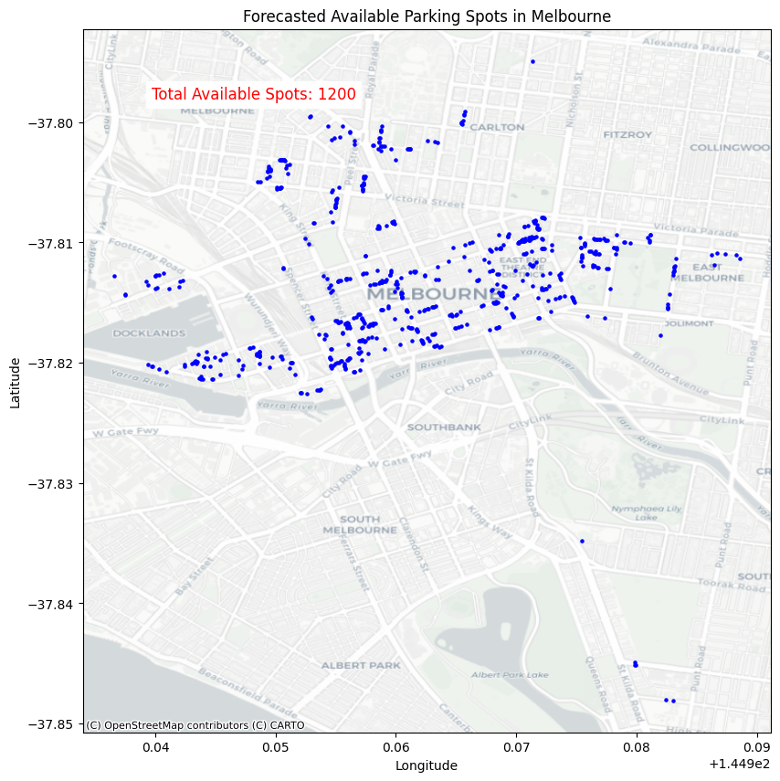

```python
import pandas as pd
import pytz
import numpy as np
import matplotlib.pyplot as plt
import geopandas as gpd
import contextily as ctx
from sklearn.preprocessing import MinMaxScaler
from sklearn.metrics import mean_squared_error
from tensorflow.keras.models import Sequential
from tensorflow.keras.layers import Dense, LSTM
import requests
from datetime import datetime, timedelta

# API details
base_url = 'https://data.melbourne.vic.gov.au/api/explore/v2.1/catalog/datasets/'
dataset_id = 'on-street-parking-bay-sensors'

# Fetch the dataset from the API
url = f"{base_url}{dataset_id}/exports/csv"
df = pd.read_csv(url, delimiter=';')

# List the column names to verify them
print("Column Names:")
print(df.columns.tolist())

# Define the timezone conversion function
def convert_utc_to_melbourne(utc_time_str):
    melbourne_zone = pytz.timezone('Australia/Melbourne')
    utc_time = pd.to_datetime(utc_time_str, utc=True)
    melbourne_time = utc_time.tz_convert(melbourne_zone)
    return melbourne_time

# Convert the specified columns
columns_to_convert = ['lastupdated', 'status_timestamp']

for column in columns_to_convert:
    if column in df.columns:
        df[column] = df[column].apply(lambda x: convert_utc_to_melbourne(x) if pd.notnull(x) else x)
        print(f"Updated Column: {column}")
    else:
        print(f"Column '{column}' not found in the data")

# Filter data to include only rows from the last hour
one_hour_ago = pd.Timestamp.now(pytz.timezone('Australia/Melbourne')) - timedelta(hours=1)
df = df[df['status_timestamp'] >= one_hour_ago]

# Calculate the total number of unique kerbside IDs in the dataset
total_kerbside_ids = df['kerbsideid'].nunique()

# Filter to include only rows where status_description is 'Present'
df_present = df[df['status_description'] == 'Present']

# Set 'status_timestamp' as the index and ensure it is in datetime format
df_present.set_index('status_timestamp', inplace=True)

# Resample data to a minute frequency to find the number of 'Present' statuses per kerbside ID
df_minutely = df_present.resample('T').agg({
    'kerbsideid': 'count'
})

# Normalize the data
scaler = MinMaxScaler(feature_range=(0, 1))
df_minutely_scaled = scaler.fit_transform(df_minutely)

# Function to create dataset matrix
def create_dataset(dataset, look_back=1):
    X, Y = [], []
    for i in range(len(dataset) - look_back - 1):
        a = dataset[i:(i + look_back), 0]
        X.append(a)
        Y.append(dataset[i + look_back, 0])
    return np.array(X), np.array(Y)

# Prepare the dataset for LSTM
look_back = 1
X, Y = create_dataset(df_minutely_scaled, look_back)

# Reshape input to be [samples, time steps, features]
X = np.reshape(X, (X.shape[0], 1, X.shape[1]))

# Split into train and test sets
train_size = int(len(X) * 0.8)
test_size = len(X) - train_size
X_train, X_test = X[0:train_size], X[train_size:]
Y_train, Y_test = Y[0:train_size], Y[train_size:]

# Build LSTM Model
model = Sequential()
model.add(LSTM(100, input_shape=(1, look_back)))
model.add(Dense(1))
model.compile(loss='mean_squared_error', optimizer='adam')

# Train the model
model.fit(X_train, Y_train, epochs=100, batch_size=1, verbose=2)

# Make predictions
train_predict = model.predict(X_train)
test_predict = model.predict(X_test)

# Invert predictions to original scale
train_predict = scaler.inverse_transform(train_predict)
trainY = scaler.inverse_transform([Y_train])
test_predict = scaler.inverse_transform(test_predict)
testY = scaler.inverse_transform([Y_test])

# Calculate RMSE
train_score = np.sqrt(mean_squared_error(trainY[0], train_predict[:, 0]))
print(f'Train Score: {train_score:.2f} RMSE')
test_score = np.sqrt(mean_squared_error(testY[0], test_predict[:, 0]))
print(f'Test Score: {test_score:.2f} RMSE')

# Forecast the occupied spots for the next minute
forecast_occupied = model.predict(X_test[-1].reshape(1, 1, look_back))
forecast_occupied = scaler.inverse_transform(forecast_occupied)

# Calculate available spots
forecast_available = total_kerbside_ids - forecast_occupied[0][0]

# Round to the nearest integer
forecast_available_rounded = round(forecast_available)

# Print the number of available spots
print(f"\nForecasted Available Parking Spots (next minute): {forecast_available_rounded}")

# Identify available kerbside IDs based on the prediction
df_available = df[~df['kerbsideid'].isin(df_present['kerbsideid'].unique())]

# Get the unique kerbside IDs and their locations
available_kerbside_ids = df_available[['kerbsideid', 'location']].drop_duplicates()

# Print the available kerbside IDs and their locations
print("\nAvailable Kerbside IDs and Their Locations:")
print(available_kerbside_ids)

# Convert location to separate latitude and longitude columns
available_kerbside_ids[['Latitude', 'Longitude']] = available_kerbside_ids['location'].str.split(',', expand=True)
available_kerbside_ids['Latitude'] = available_kerbside_ids['Latitude'].astype(float)
available_kerbside_ids['Longitude'] = available_kerbside_ids['Longitude'].astype(float)

# Write the available kerbside IDs and locations to a CSV file
output_file = 'available_kerbside_ids.csv'
available_kerbside_ids.to_csv(output_file, index=False)
print(f"\nAvailable kerbside IDs and their locations have been written to {output_file}")

# Plot available spots on a map
gdf = gpd.GeoDataFrame(available_kerbside_ids, geometry=gpd.points_from_xy(available_kerbside_ids.Longitude, available_kerbside_ids.Latitude))

# Plot the available parking spots
gdf = gdf.set_crs(epsg=4326)  # Set the coordinate reference system to WGS84
ax = gdf.plot(figsize=(10, 10), color='blue', markersize=5)

# Add basemap using contextily
ctx.add_basemap(ax, crs=gdf.crs, source=ctx.providers.CartoDB.Positron)

# Add text annotation for total available spots
ax.annotate(f"Total Available Spots: {forecast_available_rounded}",
            xy=(0.1, 0.9), xycoords='axes fraction', fontsize=12, color='red',
            backgroundcolor='white')

plt.title('Forecasted Available Parking Spots in Melbourne')
plt.xlabel('Longitude')
plt.ylabel('Latitude')

# Force display of plot
plt.show()
```

### 5.1. Short-Term Prediction

Here , I prefer 1 hour , 30 minutes and 15 minutes time intervals to make a comparision on data to underststand which interval is suitable for my dataset.

```
Column Names:
['lastupdated', 'status_timestamp', 'zone_number', 'status_description', 'kerbsideid', 'location']
Updated Column: lastupdated
Updated Column: status_timestamp
Resampled data shape: (3, 1)
```

```
1/1 - 1s - 1s/step - loss: 0.8607
1/1 - 0s - 50ms/step - loss: 0.8456
1/1 - 0s - 43ms/step - loss: 0.8307
1/1 - 0s - 41ms/step - loss: 0.8159
1/1 - 0s - 45ms/step - loss: 0.8012
1/1 - 0s - 43ms/step - loss: 0.7873
1/1 - 0s - 44ms/step - loss: 0.7737
1/1 - 0s - 115ms/step - loss: 0.7608
1/1 - 0s - 54ms/step - loss: 0.7480
1/1 - 0s - 44ms/step - loss: 0.7353
1/1 - 0s - 43ms/step - loss: 0.7227
1/1 - 0s - 43ms/step - loss: 0.7103
1/1 - 0s - 45ms/step - loss: 0.6979
1/1 - 0s - 44ms/step - loss: 0.6856
1/1 - 0s - 45ms/step - loss: 0.6735
1/1 - 0s - 46ms/step - loss: 0.6615
1/1 - 0s - 48ms/step - loss: 0.6495
1/1 - 0s - 43ms/step - loss: 0.6377
1/1 - 0s - 43ms/step - loss: 0.6260
1/1 - 0s - 46ms/step - loss: 0.6144
1/1 - 0s - 47ms/step - loss: 0.6029
1/1 - 0s - 44ms/step - loss: 0.5915
1/1 - 0s - 45ms/step - loss: 0.5803
1/1 - 0s - 44ms/step - loss: 0.5691
1/1 - 0s - 45ms/step - loss: 0.5581
1/1 - 0s - 44ms/step - loss: 0.5472
1/1 - 0s - 48ms/step - loss: 0.5364
1/1 - 0s - 44ms/step - loss: 0.5257
1/1 - 0s - 47ms/step - loss: 0.5151
1/1 - 0s - 48ms/step - loss: 0.5047
1/1 - 0s - 46ms/step - loss: 0.4944
1/1 - 0s - 44ms/step - loss: 0.4842
1/1 - 0s - 43ms/step - loss: 0.4742
1/1 - 0s - 44ms/step - loss: 0.4648
1/1 - 0s - 45ms/step - loss: 0.4554
1/1 - 0s - 51ms/step - loss: 0.4461
1/1 - 0s - 45ms/step - loss: 0.4369
1/1 - 0s - 47ms/step - loss: 0.4278
1/1 - 0s - 45ms/step - loss: 0.4187
1/1 - 0s - 43ms/step - loss: 0.4098
```

[output cut: 71 more lines]

```
2546       65112    -37.81023362406719, 144.9689236847353
2547       65167  -37.810643554488905, 144.96786024613817
2554       65567  -37.813491215768735, 144.95811837961972
2556       65560   -37.81343025022676, 144.95832711066356
2557       65551   -37.81332963316226, 144.95867229615575
...          ...                                      ...
6250       62349    -37.81820345794348, 144.9574635295486
6251       54321   -37.81415024868862, 144.96043413985802
6253       51620  -37.815859655649945, 144.96962898624355
6254       53227   -37.81273085753364, 144.96235890366904
6258       53226   -37.81278168256417, 144.96238231051336

[648 rows x 2 columns]

Available kerbside IDs and their locations have been written to available_kerbside_ids30min.csv
```

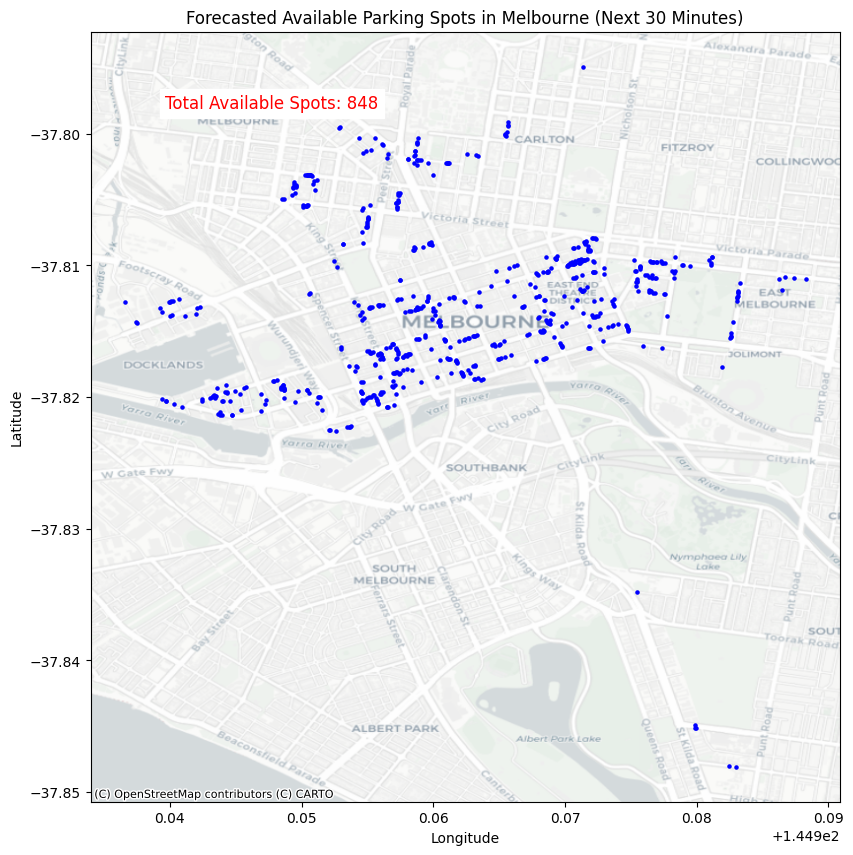

```python
import pandas as pd
import pytz
import numpy as np
import matplotlib.pyplot as plt
import geopandas as gpd
import contextily as ctx
from sklearn.preprocessing import MinMaxScaler
from sklearn.metrics import mean_squared_error
from tensorflow.keras.models import Sequential
from tensorflow.keras.layers import Dense
import requests
from datetime import datetime, timedelta

# API details
base_url = 'https://data.melbourne.vic.gov.au/api/explore/v2.1/catalog/datasets/'
dataset_id = 'on-street-parking-bay-sensors'

# Fetch the dataset from the API
url = f"{base_url}{dataset_id}/exports/csv"
df = pd.read_csv(url, delimiter=';')

# List the column names to verify them
print("Column Names:")
print(df.columns.tolist())

# Define the timezone conversion function
def convert_utc_to_melbourne(utc_time_str):
    melbourne_zone = pytz.timezone('Australia/Melbourne')
    utc_time = pd.to_datetime(utc_time_str, utc=True)
    melbourne_time = utc_time.tz_convert(melbourne_zone)
    return melbourne_time

# Convert the specified columns
columns_to_convert = ['lastupdated', 'status_timestamp']

for column in columns_to_convert:
    if column in df.columns:
        df[column] = df[column].apply(lambda x: convert_utc_to_melbourne(x) if pd.notnull(x) else x)
        print(f"Updated Column: {column}")
    else:
        print(f"Column '{column}' not found in the data")

# Option 2: Extend the data collection interval to 1 hour
one_hour_ago = pd.Timestamp.now(pytz.timezone('Australia/Melbourne')) - timedelta(hours=1)
df = df[df['status_timestamp'] >= one_hour_ago]

# Calculate the total number of unique kerbside IDs in the dataset
total_kerbside_ids = df['kerbsideid'].nunique()

# Filter to include only rows where status_description is 'Present'
df_present = df[df['status_description'] == 'Present']

# Set 'status_timestamp' as the index and ensure it is in datetime format
df_present.set_index('status_timestamp', inplace=True)

# Resample data to a 30-minute frequency to find the number of 'Present' statuses per kerbside ID
df_30min = df_present.resample('30T').agg({
    'kerbsideid': 'count'
})

# Check if there are enough data points
print(f"Resampled data shape: {df_30min.shape}")

# Normalize the data
scaler = MinMaxScaler(feature_range=(0, 1))
df_30min_scaled = scaler.fit_transform(df_30min)

# Function to create dataset matrix
def create_dataset(dataset, look_back=1):
    X, Y = [], []
    for i in range(len(dataset) - look_back):
        a = dataset[i:(i + look_back), 0]
        X.append(a)
        Y.append(dataset[i + look_back, 0])
    return np.array(X), np.array(Y)

# Further reduce the look_back to 1 if needed
look_back = 1
X, Y = create_dataset(df_30min_scaled, look_back)

# Check if X has enough data points
if X.size == 0:
    raise ValueError("Not enough data points to create dataset. Try increasing the data collection interval.")

# Reshape input to be [samples, features]
X = np.reshape(X, (X.shape[0], look_back))

# Split into train and test sets
train_size = int(len(X) * 0.8)
test_size = len(X) - train_size
X_train, X_test = X[0:train_size], X[train_size:]
Y_train, Y_test = Y[0:train_size], Y[train_size:]

# Build a simple Dense Model instead of LSTM
model = Sequential()
model.add(Dense(50, input_dim=look_back, activation='relu'))
model.add(Dense(1))
model.compile(loss='mean_squared_error', optimizer='adam')

# Train the model
model.fit(X_train, Y_train, epochs=100, batch_size=1, verbose=2)

# Make predictions
train_predict = model.predict(X_train)
test_predict = model.predict(X_test)

# Invert predictions to original scale
train_predict = scaler.inverse_transform(train_predict)
trainY = scaler.inverse_transform([Y_train])
test_predict = scaler.inverse_transform(test_predict)
testY = scaler.inverse_transform([Y_test])

# Calculate RMSE
train_score = np.sqrt(mean_squared_error(trainY[0], train_predict[:, 0]))
print(f'Train Score: {train_score:.2f} RMSE')
test_score = np.sqrt(mean_squared_error(testY[0], test_predict[:, 0]))
print(f'Test Score: {test_score:.2f} RMSE')

# Forecast the occupied spots for the next 30 minutes
forecast_occupied = model.predict(X_test[-1].reshape(1, look_back))
forecast_occupied = scaler.inverse_transform(forecast_occupied)

# Calculate available spots
forecast_available = total_kerbside_ids - forecast_occupied[0][0]

# Round to the nearest integer
forecast_available_rounded = round(forecast_available)

# Print the number of available spots
print(f"\nForecasted Available Parking Spots (next 30 minutes): {forecast_available_rounded}")

# Identify available kerbside IDs based on the prediction
df_available = df[~df['kerbsideid'].isin(df_present['kerbsideid'].unique())]

# Get the unique kerbside IDs and their locations
available_kerbside_ids = df_available[['kerbsideid', 'location']].drop_duplicates()

# Print the available kerbside IDs and their locations
print("\nAvailable Kerbside IDs and Their Locations:")
print(available_kerbside_ids)

# Convert location to separate latitude and longitude columns
available_kerbside_ids[['Latitude', 'Longitude']] = available_kerbside_ids['location'].str.split(',', expand=True)
available_kerbside_ids['Latitude'] = available_kerbside_ids['Latitude'].astype(float)
available_kerbside_ids['Longitude'] = available_kerbside_ids['Longitude'].astype(float)

# Write the available kerbside IDs and locations to a CSV file
output_file = 'available_kerbside_ids30min.csv'
available_kerbside_ids.to_csv(output_file, index=False)
print(f"\nAvailable kerbside IDs and their locations have been written to {output_file}")

# Plot available spots on a map
gdf = gpd.GeoDataFrame(available_kerbside_ids, geometry=gpd.points_from_xy(available_kerbside_ids.Longitude, available_kerbside_ids.Latitude))

# Plot the available parking spots
gdf = gdf.set_crs(epsg=4326)  # Set the coordinate reference system to WGS84
ax = gdf.plot(figsize=(10, 10), color='blue', markersize=5)

# Add basemap using contextily
ctx.add_basemap(ax, crs=gdf.crs, source=ctx.providers.CartoDB.Positron)

# Add text annotation for total available spots
ax.annotate(f"Total Available Spots: {forecast_available_rounded}",
            xy=(0.1, 0.9), xycoords='axes fraction', fontsize=12, color='red',
            backgroundcolor='white')

plt.title('Forecasted Available Parking Spots in Melbourne (Next 30 Minutes)')
plt.xlabel('Longitude')
plt.ylabel('Latitude')

# Force display of plot
plt.show()
```

### 5.2. Further Analysis on prediction - Interpretation on Strategies

15 Minute Data Set for Prediction

The code is giving error because of the low time interval, There is only 2 option to solve this problem,

Strategy 1: Increase the Data Collection Interval Instead of limiting the data to the last 15 minutes, you can extend the interval to collect more data points.

Strategy 2: Reduce the Look-Back Parameter If increasing the data collection interval is not enough, reduce the look_back parameter to 1, meaning the model will only use the previous data point to predict the next one.

For strategy 2, I reduced the look-parameter to solve the issue, but still there is an error bacause 'The training set is too small to train the model; I tried again to reduce the number of epochs. Epochs Reduced to 5: The number of epochs has been further reduced to 5, ensuring the training process is quick and suitable for small datasets. The code is still not working, the training data set is still too small to look for the patterns. For Strategy1 , i tried LSTM(worked only in 1 hour or much longer time interval) and Simple Dense Model(worked between 30 minutes and 1 hour) . I decided to change the model,

Proposed Models: *********************************************************************************

*ARIMA (AutoRegressive Integrated Moving Average) ARIMA is a statistical model that is particularly well-suited for time series forecasting. It is a good tool for small datasets

*Prophet by Facebook Prophet is a forecasting tool developed by Facebook, designed to handle time series data. It can work well with small datasets.

*Support Vector Regression (SVR) SVR can be applied to time series forecasting by treating the problem as a regression task. It is very effective for datasets with noise and small sample sizes.

********************************1st Prophet - Test -Worked on 15 minutes Time Interval

Found an error in the code. From the error I understand Prophet does not support timezones in the ds (datetime) column. To solving this, I removed the timezone information from the ds column before passing the data to Prophet.

*Remove timezone information from the 'ds' (datetime) column df_prophet['ds'] = df_prophet['ds'].dt.tz_localize(None)

Removing timezone information from the dataset before using the Prophet model means we are converting all the timestamps to a naive datetime format (a datetime without timezone awareness)

Loss of Timezone Awareness

When I remove the timezone information, my datetime values no longer account for timezone differences. This can cause issues if my data use multiple time zones.

Another problem is Daylight Saving Time (DST): Without timezone information, daylight saving time (DST) is not considered. For example, if my data includes timestamps during a DST change, I may have an hour that is effectively duplicated or missing.

*ARIMA (AutoRegressive Integrated Moving Average)********************************

#### 5.2.1. MODEL - prophet - 15 MINUTES TIME INTERVAL

```
Column Names:
['lastupdated', 'status_timestamp', 'zone_number', 'status_description', 'kerbsideid', 'location']
Updated Column: lastupdated
```

```
Updated Column: status_timestamp
```

```
16:49:04 - cmdstanpy - INFO - Chain [1] done processing
```

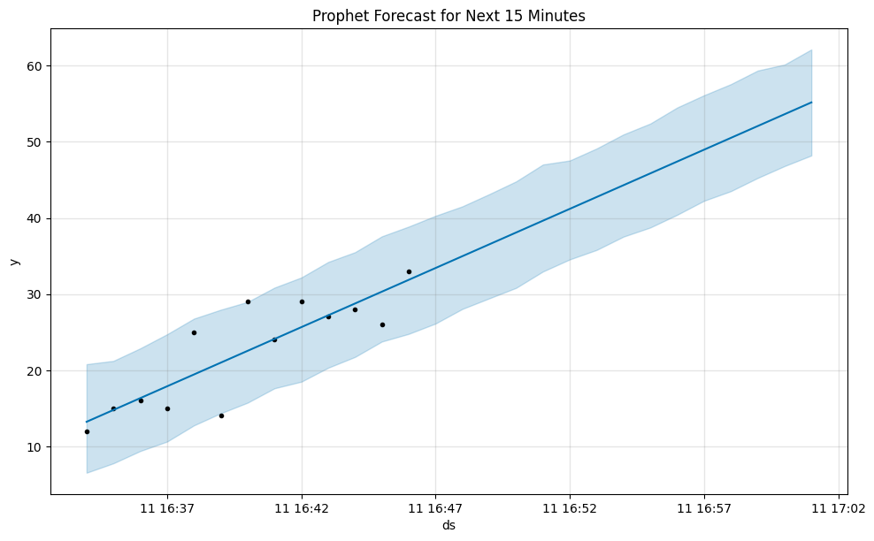

```
Forecasted Available Parking Spots (next 15 minutes): 19

Available Kerbside IDs and Their Locations:
      kerbsideid                                 location
2544       50669   -37.80878490795517, 144.97173126985038
2550       50637   -37.80875480843041, 144.97184279187314
2606       65853   -37.80878448812302, 144.97048656633723
2620       52214  -37.810322721075494, 144.96709005970536
2629       62315   -37.81780450336542, 144.95828438269166
...          ...                                      ...
6245       66221  -37.811621249789724, 144.96068101888056
6248       63330  -37.817859431042564, 144.95432048911783
6249       54152   -37.81653727723833, 144.96128264921094
6250       54417      -37.8134969966321, 144.960135162915
6256       54320   -37.81420358514674, 144.96045850918097

[391 rows x 2 columns]

Available kerbside IDs and their locations have been written to available_kerbside_ids15min.csv
```

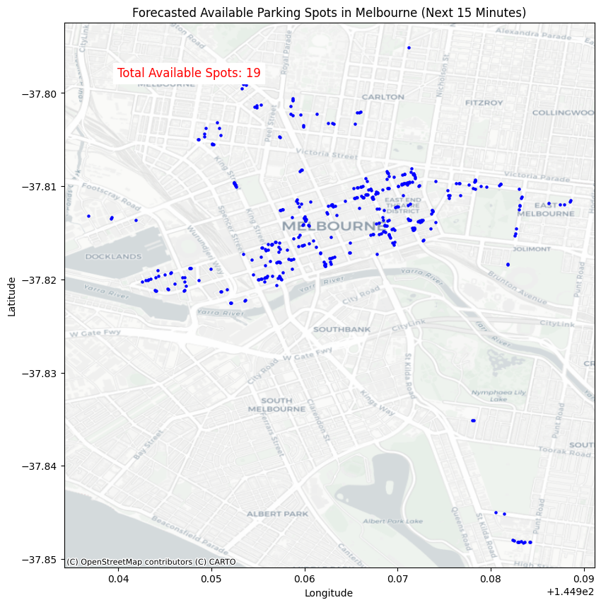

[output not shown]

```python
import pandas as pd
import pytz
import numpy as np
import matplotlib.pyplot as plt
import geopandas as gpd
import contextily as ctx
from prophet import Prophet
from datetime import datetime, timedelta

# API details
base_url = 'https://data.melbourne.vic.gov.au/api/explore/v2.1/catalog/datasets/'
dataset_id = 'on-street-parking-bay-sensors'

# Fetch the dataset from the API
url = f"{base_url}{dataset_id}/exports/csv"
df = pd.read_csv(url, delimiter=';')

# List the column names to verify them
print("Column Names:")
print(df.columns.tolist())

# Define the timezone conversion function
def convert_utc_to_melbourne(utc_time_str):
    melbourne_zone = pytz.timezone('Australia/Melbourne')
    utc_time = pd.to_datetime(utc_time_str, utc=True)
    melbourne_time = utc_time.tz_convert(melbourne_zone)
    return melbourne_time

# Convert the specified columns
columns_to_convert = ['lastupdated', 'status_timestamp']

for column in columns_to_convert:
    if column in df.columns:
        df[column] = df[column].apply(lambda x: convert_utc_to_melbourne(x) if pd.notnull(x) else x)
        print(f"Updated Column: {column}")
    else:
        print(f"Column '{column}' not found in the data")

# Filter data to include only rows from the last 15 minutes
fifteen_minutes_ago = pd.Timestamp.now(pytz.timezone('Australia/Melbourne')) - timedelta(minutes=15)
df = df[df['status_timestamp'] >= fifteen_minutes_ago]

# Calculate the total number of unique kerbside IDs in the dataset
total_kerbside_ids = df['kerbsideid'].nunique()

# Filter to include only rows where status_description is 'Present'
df_present = df[df['status_description'] == 'Present']

# Prepare data for Prophet model
df_prophet = df_present[['status_timestamp', 'kerbsideid']].resample('T', on='status_timestamp').count().reset_index()
df_prophet.columns = ['ds', 'y']

# Remove timezone information from the 'ds' column
df_prophet['ds'] = df_prophet['ds'].dt.tz_localize(None)

# Instantiate and fit the Prophet model
model = Prophet(interval_width=0.95)
model.fit(df_prophet)

# Create a dataframe to hold predictions
future = model.make_future_dataframe(periods=15, freq='T')
forecast = model.predict(future)

# Plot forecast
model.plot(forecast)
plt.title('Prophet Forecast for Next 15 Minutes')
plt.show()

# Calculate the total forecasted occupied spots for the next 15 minutes
forecast_occupied = forecast.tail(15)['yhat'].sum()
forecast_available = total_kerbside_ids - forecast_occupied

# Round to the nearest integer
forecast_available_rounded = round(forecast_available)

# Print the number of available spots
print(f"\nForecasted Available Parking Spots (next 15 minutes): {forecast_available_rounded}")

# Identify available kerbside IDs based on the prediction
df_available = df[~df['kerbsideid'].isin(df_present['kerbsideid'].unique())]

# Get the unique kerbside IDs and their locations
available_kerbside_ids = df_available[['kerbsideid', 'location']].drop_duplicates()

# Print the available kerbside IDs and their locations
print("\nAvailable Kerbside IDs and Their Locations:")
print(available_kerbside_ids)

# Convert location to separate latitude and longitude columns
available_kerbside_ids[['Latitude', 'Longitude']] = available_kerbside_ids['location'].str.split(',', expand=True)
available_kerbside_ids['Latitude'] = available_kerbside_ids['Latitude'].astype(float)
available_kerbside_ids['Longitude'] = available_kerbside_ids['Longitude'].astype(float)

# Write the available kerbside IDs and locations to a CSV file
output_file = 'available_kerbside_ids15min.csv'
available_kerbside_ids.to_csv(output_file, index=False)
print(f"\nAvailable kerbside IDs and their locations have been written to {output_file}")

# Created a Geodataframe to show the available parking spots for the next 15 minutes.
gdf = gpd.GeoDataFrame(available_kerbside_ids, geometry=gpd.points_from_xy(available_kerbside_ids.Longitude, available_kerbside_ids.Latitude))

# Plot the available parking spots
gdf = gdf.set_crs(epsg=4326)  # Set the coordinate reference system to WGS84
ax = gdf.plot(figsize=(10, 10), color='blue', markersize=5)

# Add basemap using contextily
ctx.add_basemap(ax, crs=gdf.crs, source=ctx.providers.CartoDB.Positron)

# Add text annotation for total available spots
ax.annotate(f"Total Available Spots: {forecast_available_rounded}",
            xy=(0.1, 0.9), xycoords='axes fraction', fontsize=12, color='red',
            backgroundcolor='white')

plt.title('Forecasted Available Parking Spots in Melbourne (Next 15 Minutes)')
plt.xlabel('Longitude')
plt.ylabel('Latitude')

# Force display of plot
plt.show()

# Calculate RMSE for training data
train_score = np.sqrt(mean_squared_error(trainY, train_predict))
print(f'Train Score: {train_score:.2f} RMSE')

# Calculate RMSE for testing data
test_score = np.sqrt(mean_squared_error(testY, test_predict))
print(f'Test Score: {test_score:.2f} RMSE')
```

#### 5.2.3. ARIMA Model

15 MINUTES TIME INTERVAL - ARIMA is well-suited for small datasets

```
Column Names:
['lastupdated', 'status_timestamp', 'zone_number', 'status_description', 'kerbsideid', 'location']
Updated Column: lastupdated
Updated Column: status_timestamp

Forecasted Available Parking Spots (next 15 minutes): 152

Available Kerbside IDs and Their Locations:
      kerbsideid                                location
2564       65531  -37.813135638415574, 144.9593364688236
2572        7514   -37.80827825665301, 144.9596951942212
2586        7551  -37.80850658565203, 144.95924893756137
2597       60735  -37.82075156352007, 144.95657749343093
2613       65822   -37.80867133402634, 144.9707064334778
...          ...                                     ...
6209       64249  -37.81052097557947, 144.97216029878456
6219       52311  -37.80962821227467, 144.96677028499568
6225       63224    -37.81702338829923, 144.957223551761
6242       65016  -37.80957211737984, 144.97117794858474
6258       53226  -37.81278168256417, 144.96238231051336

[276 rows x 2 columns]

Available kerbside IDs and their locations have been written to available_kerbside_ids15MIN-ARIMA.csv
```

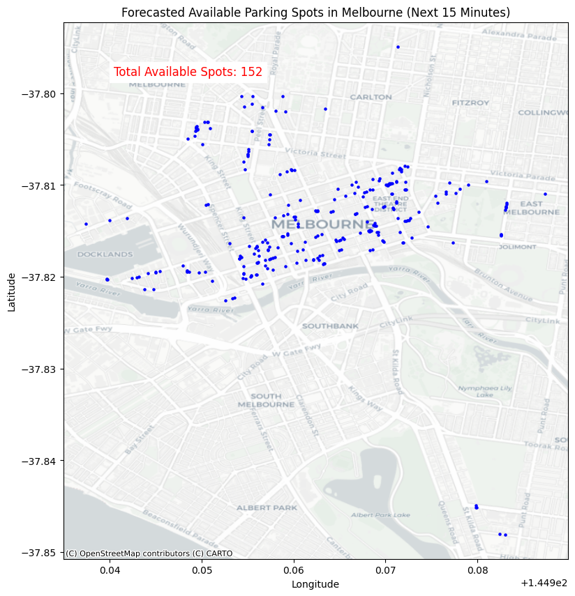

[output not shown]

```python
import pandas as pd
import pytz
import numpy as np
import matplotlib.pyplot as plt
import geopandas as gpd
import contextily as ctx
from statsmodels.tsa.arima.model import ARIMA
from datetime import datetime, timedelta

# API details
base_url = 'https://data.melbourne.vic.gov.au/api/explore/v2.1/catalog/datasets/'
dataset_id = 'on-street-parking-bay-sensors'

# Fetch the dataset from the API
url = f"{base_url}{dataset_id}/exports/csv"
df = pd.read_csv(url, delimiter=';')

# List the column names to verify them
print("Column Names:")
print(df.columns.tolist())

# Define the timezone conversion function
def convert_utc_to_melbourne(utc_time_str):
    melbourne_zone = pytz.timezone('Australia/Melbourne')
    utc_time = pd.to_datetime(utc_time_str, utc=True)
    melbourne_time = utc_time.tz_convert(melbourne_zone)
    return melbourne_time

# Convert the specified columns
columns_to_convert = ['lastupdated', 'status_timestamp']

for column in columns_to_convert:
    if column in df.columns:
        df[column] = df[column].apply(lambda x: convert_utc_to_melbourne(x) if pd.notnull(x) else x)
        print(f"Updated Column: {column}")
    else:
        print(f"Column '{column}' not found in the data")

# Filter data to include only rows from the last 15 minutes
fifteen_minutes_ago = pd.Timestamp.now(pytz.timezone('Australia/Melbourne')) - timedelta(minutes=15)
df = df[df['status_timestamp'] >= fifteen_minutes_ago]

# Calculate the total number of unique kerbside IDs in the dataset
total_kerbside_ids = df['kerbsideid'].nunique()

# Filter to include only rows where status_description is 'Present'
df_present = df[df['status_description'] == 'Present']

# Resample data to a minute frequency to find the number of 'Present' statuses per kerbside ID
df_minutely = df_present.resample('T', on='status_timestamp').agg({
    'kerbsideid': 'count'
})

# Fit an ARIMA model to the data
arima_order = (2, 1, 2)  # Example order, you may need to experiment with this
model = ARIMA(df_minutely['kerbsideid'], order=arima_order)
model_fit = model.fit()

# Forecast the number of occupied spots for the next 15 minutes
forecast = model_fit.forecast(steps=15)

# Calculate available spots
forecast_occupied = forecast.sum()
forecast_available = total_kerbside_ids - forecast_occupied

# Round to the nearest integer
forecast_available_rounded = round(forecast_available)

# Print the number of available spots
print(f"\nForecasted Available Parking Spots (next 15 minutes): {forecast_available_rounded}")

# Identify available kerbside IDs based on the prediction
df_available = df[~df['kerbsideid'].isin(df_present['kerbsideid'].unique())]

# Get the unique kerbside IDs and their locations
available_kerbside_ids = df_available[['kerbsideid', 'location']].drop_duplicates()

# Print the available kerbside IDs and their locations
print("\nAvailable Kerbside IDs and Their Locations:")
print(available_kerbside_ids)

# Convert location to separate latitude and longitude columns
available_kerbside_ids[['Latitude', 'Longitude']] = available_kerbside_ids['location'].str.split(',', expand=True)
available_kerbside_ids['Latitude'] = available_kerbside_ids['Latitude'].astype(float)
available_kerbside_ids['Longitude'] = available_kerbside_ids['Longitude'].astype(float)

# Write the available kerbside IDs and locations to a CSV file
output_file = 'available_kerbside_ids15MIN-ARIMA.csv'
available_kerbside_ids.to_csv(output_file, index=False)
print(f"\nAvailable kerbside IDs and their locations have been written to {output_file}")

# Plot available spots on a map
gdf = gpd.GeoDataFrame(available_kerbside_ids, geometry=gpd.points_from_xy(available_kerbside_ids.Longitude, available_kerbside_ids.Latitude))

# Plot the available parking spots
gdf = gdf.set_crs(epsg=4326)  # Set the coordinate reference system to WGS84
ax = gdf.plot(figsize=(10, 10), color='blue', markersize=5)

# Add basemap using contextily
ctx.add_basemap(ax, crs=gdf.crs, source=ctx.providers.CartoDB.Positron)

# Add text annotation for total available spots
ax.annotate(f"Total Available Spots: {forecast_available_rounded}",
            xy=(0.1, 0.9), xycoords='axes fraction', fontsize=12, color='red',
            backgroundcolor='white')

plt.title('Forecasted Available Parking Spots in Melbourne (Next 15 Minutes)')
plt.xlabel('Longitude')
plt.ylabel('Latitude')

# Force display of plot
plt.show()

# Calculate RMSE for training data
train_score = np.sqrt(mean_squared_error(trainY, train_predict))
print(f'Train Score: {train_score:.2f} RMSE')

# Calculate RMSE for testing data
test_score = np.sqrt(mean_squared_error(testY, test_predict))
print(f'Test Score: {test_score:.2f} RMSE')
```

#### 5.2.4. prediction- 15 minutes data interval

MODEL - Support Vector Regression (SVR) - suitable for smaller datasets and non-linear relationships. to forecast parking availability for the next 15 minutes using recent 15 minutes data.

```
Column Names:
['lastupdated', 'status_timestamp', 'zone_number', 'status_description', 'kerbsideid', 'location']
Updated Column: lastupdated
Updated Column: status_timestamp
Train Score: 1.92 RMSE
Test Score: 7.39 RMSE

Forecasted Available Parking Spots (next 15 minutes): 427

Available Kerbside IDs and Their Locations:
      kerbsideid                                location
2564       65531  -37.813135638415574, 144.9593364688236
2572        7514   -37.80827825665301, 144.9596951942212
2586        7551  -37.80850658565203, 144.95924893756137
2597       60735  -37.82075156352007, 144.95657749343093
2613       65822   -37.80867133402634, 144.9707064334778
...          ...                                     ...
6209       64249  -37.81052097557947, 144.97216029878456
6219       52311  -37.80962821227467, 144.96677028499568
6225       63224    -37.81702338829923, 144.957223551761
6242       65016  -37.80957211737984, 144.97117794858474
6258       53226  -37.81278168256417, 144.96238231051336

[269 rows x 2 columns]

Available kerbside IDs and their locations have been written to available_kerbside_idsSVR_MODEL.csv
```

[figure not shown]

```
Train Score: 1.92 RMSE
Test Score: 7.39 RMSE
```

```python
import pandas as pd
import pytz
import numpy as np
import matplotlib.pyplot as plt
import geopandas as gpd
import contextily as ctx
from sklearn.svm import SVR
from sklearn.preprocessing import MinMaxScaler
from sklearn.metrics import mean_squared_error
from datetime import datetime, timedelta

# API details
base_url = 'https://data.melbourne.vic.gov.au/api/explore/v2.1/catalog/datasets/'
dataset_id = 'on-street-parking-bay-sensors'

# Fetch the dataset from the API
url = f"{base_url}{dataset_id}/exports/csv"
df = pd.read_csv(url, delimiter=';')

# List the column names to verify them
print("Column Names:")
print(df.columns.tolist())

# Define the timezone conversion function
def convert_utc_to_melbourne(utc_time_str):
    melbourne_zone = pytz.timezone('Australia/Melbourne')
    utc_time = pd.to_datetime(utc_time_str, utc=True)
    melbourne_time = utc_time.tz_convert(melbourne_zone)
    return melbourne_time

# Convert the specified columns
columns_to_convert = ['lastupdated', 'status_timestamp']

for column in columns_to_convert:
    if column in df.columns:
        df[column] = df[column].apply(lambda x: convert_utc_to_melbourne(x) if pd.notnull(x) else x)
        print(f"Updated Column: {column}")
    else:
        print(f"Column '{column}' not found in the data")

# Filter data to include only rows from the last 15 minutes
fifteen_minutes_ago = pd.Timestamp.now(pytz.timezone('Australia/Melbourne')) - timedelta(minutes=15)
df = df[df['status_timestamp'] >= fifteen_minutes_ago]

# Calculate the total number of unique kerbside IDs in the dataset
total_kerbside_ids = df['kerbsideid'].nunique()

# Filter to include only rows where status_description is 'Present'
df_present = df[df['status_description'] == 'Present']

# Resample data to a minute frequency to find the number of 'Present' statuses per kerbside ID
df_minutely = df_present.resample('T', on='status_timestamp').agg({
    'kerbsideid': 'count'
})

# Normalize the data
scaler = MinMaxScaler(feature_range=(0, 1))
df_minutely_scaled = scaler.fit_transform(df_minutely)

# Prepare the dataset for SVR
look_back = 1
X, Y = [], []
for i in range(len(df_minutely_scaled) - look_back):
    X.append(df_minutely_scaled[i:(i + look_back), 0])
    Y.append(df_minutely_scaled[i + look_back, 0])
X, Y = np.array(X), np.array(Y)

# Reshape input to be [samples, features]
X = np.reshape(X, (X.shape[0], look_back))

# Split into train and test sets
train_size = int(len(X) * 0.8)
test_size = len(X) - train_size
X_train, X_test = X[0:train_size], X[train_size:]
Y_train, Y_test = Y[0:train_size], Y[train_size:]

# Fit the SVR model
svr_model = SVR(kernel='rbf', C=1e3, gamma=0.1)
svr_model.fit(X_train, Y_train)

# Make predictions
train_predict = svr_model.predict(X_train)
test_predict = svr_model.predict(X_test)

# Invert predictions to original scale
train_predict = scaler.inverse_transform(train_predict.reshape(-1, 1))
trainY = scaler.inverse_transform(Y_train.reshape(-1, 1))
test_predict = scaler.inverse_transform(test_predict.reshape(-1, 1))
testY = scaler.inverse_transform(Y_test.reshape(-1, 1))

# Calculate RMSE
train_score = np.sqrt(mean_squared_error(trainY, train_predict))
print(f'Train Score: {train_score:.2f} RMSE')
test_score = np.sqrt(mean_squared_error(testY, test_predict))
print(f'Test Score: {test_score:.2f} RMSE')

# Forecast the occupied spots for the next 15 minutes
forecast_occupied = svr_model.predict(X_test[-1].reshape(1, -1))
forecast_occupied = scaler.inverse_transform(forecast_occupied.reshape(-1, 1))

# Calculate available spots
forecast_available = total_kerbside_ids - forecast_occupied.sum()

# Round to the nearest integer
forecast_available_rounded = round(forecast_available)

# Print the number of available spots
print(f"\nForecasted Available Parking Spots (next 15 minutes): {forecast_available_rounded}")

# Identify available kerbside IDs based on the prediction
df_available = df[~df['kerbsideid'].isin(df_present['kerbsideid'].unique())]

# Get the unique kerbside IDs and their locations
available_kerbside_ids = df_available[['kerbsideid', 'location']].drop_duplicates()

# Print the available kerbside IDs and their locations
print("\nAvailable Kerbside IDs and Their Locations:")
print(available_kerbside_ids)

# Convert location to separate latitude and longitude columns
available_kerbside_ids[['Latitude', 'Longitude']] = available_kerbside_ids['location'].str.split(',', expand=True)
available_kerbside_ids['Latitude'] = available_kerbside_ids['Latitude'].astype(float)
available_kerbside_ids['Longitude'] = available_kerbside_ids['Longitude'].astype(float)

# Write the available kerbside IDs and locations to a CSV file
output_file = 'available_kerbside_idsSVR_MODEL.csv'
available_kerbside_ids.to_csv(output_file, index=False)
print(f"\nAvailable kerbside IDs and their locations have been written to {output_file}")

# Plot available spots on a map
gdf = gpd.GeoDataFrame(available_kerbside_ids, geometry=gpd.points_from_xy(available_kerbside_ids.Longitude, available_kerbside_ids.Latitude))

# Plot the available parking spots
gdf = gdf.set_crs(epsg=4326)  # Set the coordinate reference system to WGS84
ax = gdf.plot(figsize=(10, 10), color='blue', markersize=5)

# Add basemap using contextily
ctx.add_basemap(ax, crs=gdf.crs, source=ctx.providers.CartoDB.Positron)

# Add text annotation for total available spots
ax.annotate(f"Total Available Spots: {forecast_available_rounded}",
            xy=(0.1, 0.9), xycoords='axes fraction', fontsize=12, color='red',
            backgroundcolor='white')

plt.title('Forecasted Available Parking Spots in Melbourne (Next 15 Minutes)')
plt.xlabel('Longitude')
plt.ylabel('Latitude')

# Force display of plot
plt.show()

# Calculate RMSE for training data
train_score = np.sqrt(mean_squared_error(trainY, train_predict))
print(f'Train Score: {train_score:.2f} RMSE')

# Calculate RMSE for testing data
test_score = np.sqrt(mean_squared_error(testY, test_predict))
print(f'Test Score: {test_score:.2f} RMSE')
```